# FAERS quarterly extracts into importable CSVs

Ty Stanford of the Quality Use of Medicines and Pharmacy Research Centre (UniSA)

07 Jan 2021

# 1 Motivation

This document outlines the process of taking the ascii/text quarterly extract FAERS data available online (https://fis.fda.gov/extensions/FPD-QDE-FAERS/FPD-QDE-FAERS.html) to be imported into a database platform (PostgreSQL for example) by creating CSV files for each of the seven tables in the FAERS data:

- `demo.csv`
- `drug.csv`
- `indi.csv`
- `outc.csv`
- `reac.csv`
- `rpsr.csv`
- `ther.csv`

## 1.1 Prerequisites

- A computer with Windows 10, Linux or macOS operating systems
  - 32 GB RAM is likely needed
- Internet access (fast, ideally)
- Some knowledge of command-line shells/bash/terminals (or willing to learn!)
- Depending on your operating system above, you will need the the following program:
  - [Windows Subsystem for Linux (WSL)](https://docs.microsoft.com/en-us/windows/wsl/install-win10) in Windows 10 [I used the Ubuntu distribution]
  - bash or similar in Linux
  - Terminal in macOS
- An R installation (https://cran.r-project.org/) with additional packages (see *Setting up R session* section)

# 2 Set up

## 2.1 Set directory locations in shell/terminal

Note these locations will need to be chosen as different locations for different computers etc. You are probably best to make these absolute paths and not relative paths to avoid confusion/errors.

Below is a screenshot of my directory setup (Windows 10) and the following code is dependent on these directories.

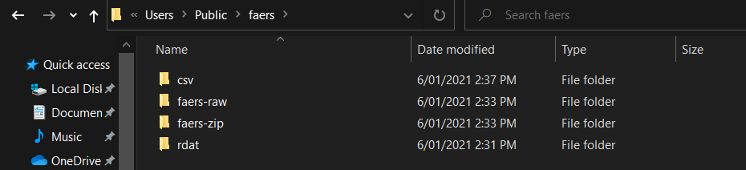

Screenshot of directory structure that corresponds to the code in this document

Run the following in bash-like shell (here I am using the Ubuntu 18.4 LTS flavoured WSL shell on windows 10, see [here](https://docs.microsoft.com/en-us/windows/wsl/install-win10), that is why the usual `C:/Users/...` location is located at `/mnt/c/Users/...`):

```bash
# this is where the zipped faers data is saved to
ZIP_LOC=/mnt/c/Users/Public/faers/faers-zip
# this is where the raw faers data is saved to after un-zipping
RAW_LOC=/mnt/c/Users/Public/faers/faers-raw
# this is where the R data_frame/tibble/.RData data is saved
DAT_LOC=/mnt/c/Users/Public/faers/rdat
# this is where the final CSVs for the DB will saved
CSV_LOC=/mnt/c/Users/Public/faers/csv
```

I have also tested on Linux, just use your usual directory path specifications for the above and below.

# 3 Obtain and modify raw FAERS quarterly extract text files

## 3.1 Download FAERS via shell/terminal

The below is a shell/bash script to download the zip files. Note the change of filename formatting in 2012 (thus two different for loops).

```bash
echo "Bash version ${BASH_VERSION}..."

# move to where we want to save zip files
cd ${ZIP_LOC}

# test by getting 2020 files
wget https://fis.fda.gov/content/Exports/faers_ascii_2020Q3.zip
wget https://fis.fda.gov/content/Exports/faers_ascii_2020Q2.zip
wget "https://fis.fda.gov/content/Exports/faers_ascii_2020Q1.zip"

# loop form 2019 down to 2013
for i in {2019..2013..-1}
do
    for j in {4..1..-1}
    do
        echo "year $i quater $j"
        wget "https://fis.fda.gov/content/Exports/faers_ascii_${i}Q${j}.zip"
    done
done

#### FUN FACT #####
# as of writing (2019-09-26), the quarterly extracts from
#   2012Q3 and prior are named "aers_ascii_YYYYQX.zip"
#   instead of "_f_aers_ascii_YYYYQX.zip" for whatever reason
#   therefore the below code covers these scenarios
###################

wget "https://fis.fda.gov/content/Exports/faers_ascii_2012Q4.zip"
wget "https://fis.fda.gov/content/Exports/aers_ascii_2012Q3.zip"
wget "https://fis.fda.gov/content/Exports/aers_ascii_2012Q2.zip"
wget "https://fis.fda.gov/content/Exports/aers_ascii_2012Q1.zip"

# loop form 2011 down to oldest data of 2004
for i in {2011..2004..-1}
do
    for j in {4..1..-1}
    do
        echo "year $i quater $j"
        wget "https://fis.fda.gov/content/Exports/aers_ascii_${i}Q${j}.zip"
    done
done
```

## 3.2 Unzip FAERS quarterly extracts programmatically in shell/terminal

The below is a shell/bash script to unzip the zip files into folders of the same name.

```bash
## NB#1: the below will work on linux and macOS platforms. Windows can run it
##       using WSL (https://docs.microsoft.com/en-us/windows/wsl/install-win10)
##       {I have testied using WSL Ubuntu derivative}
##       When using WSL note, that the User home dir is at: /mnt/c/Users/xxx/Documents/

## NB#2: zip utility can be installed on Ubuntu derivatives (including WSL)
## with the command:
# sudo apt install zip

# move to zip's location
cd ${ZIP_LOC}

# test
z=faers_ascii_2020Q3.zip
dir=$(basename $z .zip)
mkdir ${RAW_LOC}/$dir
unzip $z -d ${RAW_LOC}/$dir
# (if works delete resultant file)

# the real thing
zips=$(ls) # get names of zip files as string/space seperated vector
## or to just unzip some files do something like the following
# zips="faers_ascii_2019Q3.zip faers_ascii_2019Q4.zip faers_ascii_2020Q1.zip"
echo $zips
for z in $zips
do
    dir=$(basename $z .zip)
    mkdir ${RAW_LOC}/$dir
    unzip $z -d ${RAW_LOC}/$dir
done
```

## 3.3 Modifying text in FAERS text data files in shell/terminal

Unfortunately, the text data files (that are “$” delimited) are not ready to be imported into R. The reason is that there are some files that have different number of {$}s on the header row and in the following rows. In the offending files, the rows all finish with “$” while the header rowsdo not, resulting in one less “$”.

The easiest (but hacky) solution is to append “$nullcol” to the header rows in the text files. The below bash script does just that using `sed` (Stream EDitor).

```bash
cd ${RAW_LOC}

####
# So as it goes, there's an extra "$" on each line in the "aers" files
# we want to add a "$" to each header row so R doesn't create a warning
# when reading in the text files
####

# these are the problem files:
find -iregex "\./aers_ascii_[0-9Q]+/ascii/.*\.txt$"

files2change=$(find -iregex "\./aers_ascii_[0-9Q]+/ascii/.*\.txt$")
echo $files2change

### make substitution on first line only using sed (stream editor):
# 1 = first line
# s/ = substtute
# \(...\) = grouping to be referred to as \1 in the substitution string
# ^.*$ = start of line (^), everything in line (.*), anchored by eol (\r$)
#  [NB: the \r is the carrige return in windows txt files...]
# \1\$nullcol = replace with line found (\1) and append string "$nullcol"
# the -i option creates a backup (specifically with "bakup" appended)

# testing
# f='aers_ascii_2004Q1/ascii/DEMO04Q1.TXT'
for f in $files2change
do
  echo "Adding col to header using sed on: $f"
  sed -ibakup "1 s/^\(.*\)\r$/\1\$nullcol/" $f
done



###
# These files for whatever reason in the "aers" data had the right no of cols
# Specifically, the INDIcation datasets
# so... re-instate the backups
##

# these are the INDI "aers era" files:
find -iregex "\./aers_ascii_[0-9Q]+/ascii/INDI.*\.txt$"

files2change=$(find -iregex "\./aers_ascii_[0-9Q]+/ascii/INDI.*\.txt$")
echo $files2change

# should look like a list as below (most likely in a different order):
# aers_ascii_2004Q1/ascii/INDI04Q1.TXT aers_ascii_2004Q2/ascii/INDI04Q2.TXT
# ...  aers_ascii_2012Q3/ascii/INDI12Q3.TXT'

for f in $files2change
do
  echo "Removing $f so ${f}bakup can be re-instated "
  rm -fv $f
  mv ${f}bakup $f
done
```

### 3.3.1 How to reverse changes if anything goes wrong

In case it is required….

```bash
####
# if didn't work, reverse changes
####
for f in $files2change
do
  echo "Removing $f so ${f}bakup can be re-instated "
  rm -fv $f
done


for f in $files2change
do
  echo "Re-instating ${f}bakup as $f"
  mv ${f}bakup $f
done
```

# 4 Check the data files can be imported into R without error/warning

```r
## this code assumes you are in the $RAW_LOC folder used in the bash scripts
## to do this you might run the following commented R code:
# RAW_LOC <- "C:/Users/Public/faers/faers-raw"
# setwd(RAW_LOC)

library(knitr)
library(readr)
library(tidyr)
library(stringr)
library(tibble)
library(dplyr)
library(ggplot2)

# these are the text data files
tab_files <-
   list.files(
     path = ".", # assuming you are in RAW_LOC location
     pattern = ".*\\.(TXT|txt)$",
     all.files = FALSE,
     full.names = FALSE,
     recursive = TRUE,
     ignore.case = FALSE,
     include.dirs = FALSE,
     no.. = FALSE
   )

# keep only data in the "ascii" subfolders
tab_files <-
  tab_files[
    grepl(".*(fa|a)ers\\_ascii\\_[0-9Q]+/(ascii|ASCII)/.*\\.(TXT|txt)$", tab_files)
  ]
# remove the STAT.TXT files
(tab_files <- tab_files[!grepl("(stat|STAT)", tab_files)])
(n_tab <- length(tab_files))

# mprint a summary of files (should be 7 for each quarter)
years <- gsub(".*\\_([0-9]+)Q[1-4]/.*",   "\\1", tab_files)
qtrs  <- gsub(".*\\_([0-9]+)Q([1-4])/.*", "\\2", tab_files)
kable(table(years, qtrs))


# loop through files to count "$"s in the header and rows
offending_files <- NULL
for (i in 1:n_tab) { # i <- 1
  ten_lines <-
    read_lines(
      file = tab_files[i],
      skip = 0,
      skip_empty_rows = FALSE,
      n_max = 10L,
      progress = show_progress()
    )
  delims_count <- str_count(ten_lines, "\\$")
  header_and_row_ok <-
    isTRUE(all.equal(delims_count, rep(max(delims_count), length(delims_count))))
  cat(
    "For file:", tab_files[i],
    "it is", header_and_row_ok,
    "that it has the correct number of delimiters in header and rows",
    ifelse(
      header_and_row_ok,
      "\n",
      paste0("(h=", delims_count[1], "/rows=", delims_count[2], ")\n")
    )
  )
  if (!header_and_row_ok)
    offending_files <- c(offending_files, tab_files[i])

}

# print offending files
paste(offending_files, collapse = " ")
offending_files
```

# 5 Setting up R session

All previous code is run at the shell, however the below sections are R code.

The R session needs the same directory location variables as the shell code previously:

```r
# this is where the zipped faers data is saved to
ZIP_LOC <- "C:/Users/Public/faers/faers-zip"
# this is where the raw faers data is saved to after un-zipping
RAW_LOC <- "C:/Users/Public/faers/faers-raw"
# this is where the R data_frame/tibble/.RData data is saved
DAT_LOC <- "C:/Users/Public/faers/rdat"
# this is where the final CSVs for the DB will saved
CSV_LOC <- "C:/Users/Public/faers/csv"
```

Make a note of the system time when we start this process below for posterity.

```r
# start time of process
(time_srt <- format(Sys.time(), '%Y-%m-%d %H:%M:%S'))
```

```
## [1] "2021-01-07 17:41:01"
```

## 5.1 Libraries that will be used

```r
library(knitr)
library(readr)
library(tidyr)
library(stringr)
library(tibble)
library(dplyr)
library(ggplot2)
library(foreach)
library(tidyselect)
library(lubridate)
```

# 6 Explore FAERS text extracts

The following section looks at the FAERS quarterly extract files and checks each table (`demo`, `drug`, `indi`, `outc`, `reac`, `rpsr`, `ther`) is present for each quarter and the common column names in those quarters. Graphs are produce to show these.

## 6.1 Functions for exploration

```r
get_tab_files <- function(tab_nm, LOC) {

  t1 <- tolower(tab_nm)
  t2 <- toupper(tab_nm)

  pat_str <-
    paste0(
      ".*(", t1,"|", t2,").*\\.(TXT|txt)$"
    )
  cat("Table search string is:", pat_str)

  return(list.files(
    path = LOC,
    pattern = pat_str,
    all.files = FALSE,
    full.names = FALSE,
    recursive = TRUE,
    ignore.case = FALSE,
    include.dirs = FALSE,
    no.. = FALSE
  ))

}

print_yr_qtr <- function(files) {
  years <- gsub(".*\\_([0-9]+)Q([1-4])/.*", "\\1", files)
  qtrs  <- gsub(".*\\_([0-9]+)Q([1-4])/.*", "\\2", files)
  return(kable(table(years, qtrs)))
}

### This function reads in the first row of each file specified (`filenames`)
###   and keeps a record of the column names so we can determine common fields
###   over time as well as getting the number of columns for each file
###   function returns a list, the first named element (`cols_summ`) is a data.frame
###   that indicates whether columns are present in each table and the second named
###   element (`n_cols`) is the number of columns in each table
###
get_tab_summ <- function(filenames, LOC) {

  cols_summ <- # this is a summary of columns
    n_cols <- # a vector of column numbers for each file
    NULL
  for (i in seq_along(filenames)) {

    this_tab <- read_delim(paste0(LOC, "/", filenames[i]), delim = "$", n_max = 1)
    this_cols <- tibble(cols = str_to_lower(colnames(this_tab)))
    this_y <- gsub(".*\\_([0-9]+)Q([1-4])/.*", "\\1", filenames[i])
    this_q <- gsub(".*\\_([0-9]+)Q([1-4])/.*", "\\2", filenames[i])
    this_junc <- paste0(this_y, "Q", this_q)
    this_cols[[this_junc]] <- 1L
    # this_cols
    if (i == 1) {
      cols_summ <- this_cols
    } else {
      cols_summ <- full_join(cols_summ, this_cols, "cols")
    }
    this_nc <- ncol(this_tab)
    names(this_nc) <- this_junc
    n_cols <- c(n_cols, this_nc)

  }

  return(list(cols_summ = cols_summ, n_cols = n_cols))

}

col_present_plot <- function(dat) {

  pp <-
    dat %>%
    gather("year_q", "have_col", -cols) %>%
    mutate(have_col = ifelse(is.na(have_col), 0, have_col)) %>%
    ggplot(aes(year_q, cols, fill = factor(have_col))) +
      geom_tile() +
      theme(axis.text.x = element_text(angle = 90)) +
      labs(y = "Table name", x = "Year and quarter", fill = "Column\npresent")

  return(pp)

}

import_qtr_data <- function(tab_nm, IN_LOC, OUT_LOC) {

  tab_files <- get_tab_files(tab_nm, IN_LOC)
  summ_obj <- get_tab_summ(tab_files, IN_LOC)

  n_tabs <- length(tab_files)
  tab_list <- vector(mode = "list", length = n_tabs)
  years <- gsub(".*\\_([0-9]+)Q([1-4])/.*", "\\1", tab_files)
  qtrs  <- gsub(".*\\_([0-9]+)Q([1-4])/.*", "\\2", tab_files)
  names(tab_list) <- paste0(years, "Q", qtrs)

  for (i in 1:n_tabs) {

    this_tab <-
      read_delim(
        paste0(IN_LOC, "/", tab_files[i]),
        delim = "$",
        col_types = paste0(rep("c", summ_obj$n_cols[i]), collapse = "")
      )
    colnames(this_tab) <- str_to_lower(colnames(this_tab))
    this_tab[["qtr"]] <- names(tab_list)[i]
    tab_list[[i]] <- this_tab

  }

  list_nm <- paste0(tolower(tab_nm), "_list")
  assign(list_nm, tab_list, envir = globalenv())
  rm(tab_list) # save space
  save(list = list_nm, file = paste0(OUT_LOC, "/", list_nm, ".RData"))

  return(TRUE)

}

print_probs <- function(list_of_dfs) {
  n_dfs <- length(list_of_dfs)
  all_probs <- NULL
  for (i in 1:n_dfs) {
    this_probs <- problems(list_of_dfs[[i]])
    if (nrow(this_probs) > 0) {
      this_probs$df_name <- names(list_of_dfs)[i]
      all_probs <- bind_rows(all_probs, this_probs)
    }
  }
  return(all_probs)
}
```

## 6.2 View common files over time

```r
# get all text files at the RAW_LOC location
tab_files <-
   list.files(
     path = RAW_LOC,
     pattern = ".+\\.(TXT|txt)$",
     all.files = FALSE,
     full.names = FALSE,
     recursive = TRUE,
     ignore.case = FALSE,
     include.dirs = FALSE,
     no.. = FALSE
   )
# need to be part of the "ascii" subfolder
tab_files <- tab_files[grepl("[a-zA-Z0-9\\_]+/(ASCII|ascii)/", tab_files)]
head(tab_files)
```

```
## [1] "aers_ascii_2004Q1/ascii/DEMO04Q1.TXT"
## [2] "aers_ascii_2004Q1/ascii/DRUG04Q1.TXT"
## [3] "aers_ascii_2004Q1/ascii/INDI04Q1.TXT"
## [4] "aers_ascii_2004Q1/ascii/OUTC04Q1.TXT"
## [5] "aers_ascii_2004Q1/ascii/REAC04Q1.TXT"
## [6] "aers_ascii_2004Q1/ascii/RPSR04Q1.TXT"
```

```r
# get the table names from filenames
tabs <- gsub("^[a-zA-Z0-9\\_]+/(ASCII|ascii)/(.*)\\.(txt|TXT)$", "\\2", tab_files)
tabs <- gsub("_new$", "", tabs) # standardise some files with "_new" appended to them
tabs <- str_to_upper(tabs) # standardise further
head(tabs)
```

```
## [1] "DEMO04Q1" "DRUG04Q1" "INDI04Q1" "OUTC04Q1" "REAC04Q1" "RPSR04Q1"
```

```r
# check all text files fit expectation of 8 characters in form of xxxxyyQz where:
# xxxx is table name, yy is the year, Q is literal and z is the quarter)
all_tabs <-
  tibble(tab_raw = tabs) %>%
  mutate(nchar = nchar(tab_raw))

with(all_tabs, table(nchar, useNA = "ifany"))
```

```
## nchar
##   8
## 504
```

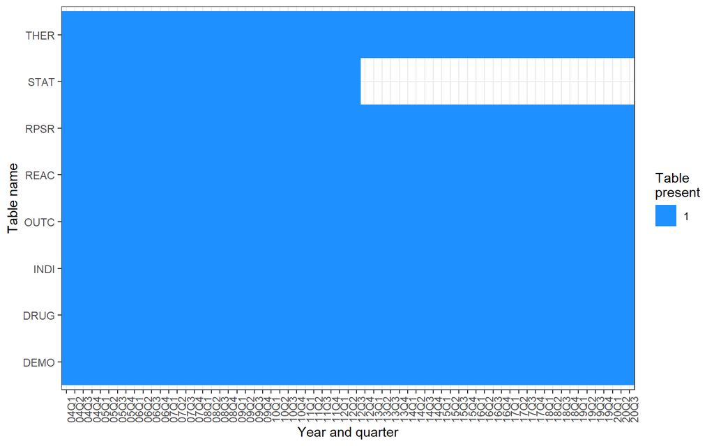

```r
all_tabs <-
  all_tabs %>%
  mutate(
    tab = str_sub(tab_raw, 1, 4),
    yr_qtr = str_sub(tab_raw, 5, 8),
    yr = str_sub(yr_qtr, 1, 2),
    qtr = str_sub(yr_qtr, 4, 4),
    present = 1
  )

# plot the presence of tables over time
all_tabs %>%
  ggplot(aes(yr_qtr, tab, fill = factor(present))) +
  geom_tile() +
  theme_bw() +
  theme(axis.text.x = element_text(angle = 90)) +
  scale_fill_manual(values = "dodgerblue") +
  labs(y = "Table name", x = "Year and quarter", fill = "Table\npresent")
```

## 6.3 Check common columns over extracts for each table

### 6.3.1 DEMO table

```r
# get demo files
demo_files <-
  list.files(
    path = RAW_LOC,
    pattern = ".*(DEMO|demo).*\\.(TXT|txt)$",
    all.files = FALSE,
    full.names = FALSE,
    recursive = TRUE,
    ignore.case = FALSE,
    include.dirs = FALSE,
    no.. = FALSE
  )

(n_demo <- length(demo_files))
```

```
## [1] 67
```

```r
years <- gsub(".*\\_([0-9]+)Q([1-4])/.*", "\\1", demo_files)
qtrs  <- gsub(".*\\_([0-9]+)Q([1-4])/.*", "\\2", demo_files)
# kable(table(years, qtrs))

# test an import
read_delim(paste0(RAW_LOC, "/", demo_files[1]), delim = "$", n_max = 10)
```

```
## # A tibble: 10 x 23
##       ISR   CASE I_F_COD FOLL_SEQ IMAGE EVENT_DT MFR_DT FDA_DT REPT_COD MFR_NUM
##     <dbl>  <dbl> <chr>      <dbl> <chr>    <dbl>  <dbl>  <dbl> <chr>    <chr>
##  1 4.20e6 5.66e6 I             NA 4204~ 20030815 2.00e7 2.00e7 EXP      DL2003~
##  2 4.21e6 5.66e6 I             NA 4214~ 20010101 2.00e7 2.00e7 EXP      USA-20~
##  3 4.22e6 3.89e6 F              1 4223~ 20021028 2.00e7 2.00e7 EXP      NSADSS~
##  4 4.25e6 3.94e6 F              1 4250~       NA 2.00e7 2.00e7 EXP      NSADSS~
##  5 4.26e6 5.66e6 I             NA 4261~ 20010101 2.00e7 2.00e7 EXP      200312~
##  6 4.26e6 4.01e6 F             NA 4261~ 20030604 2.00e7 2.00e7 EXP      200313~
##  7 4.26e6 4.04e6 F             NA 4261~ 20031111 2.00e7 2.00e7 EXP      200313~
##  8 4.26e6 4.04e6 F             NA 4261~ 20031114 2.00e7 2.00e7 EXP      200321~
##  9 4.26e6 4.05e6 F             NA 4261~ 20031125 2.00e7 2.00e7 EXP      200314~
## 10 4.26e6 4.05e6 I             NA 4261~ 20031122 2.00e7 2.00e7 EXP      200320~
## # ... with 13 more variables: MFR_SNDR <chr>, AGE <dbl>, AGE_COD <chr>,
## #   GNDR_COD <chr>, E_SUB <chr>, WT <dbl>, WT_COD <chr>, REPT_DT <dbl>,
## #   OCCP_COD <chr>, DEATH_DT <lgl>, TO_MFR <lgl>, CONFID <lgl>, nullcol <lgl>
```

```r
## NB that R tries to guess column types but this can create issues when
##   identifier/primary ID columns are stored as doubles (i.e. loss of information)
##   So.... I will read in the the first line of each demo file
##   and get the number of columns. With this information I can specify for the
##   proper data import I want all `n` columns to be character variables (no info loss)
##   (conversion of data types can be done later)


summ <- get_tab_summ(demo_files, LOC = RAW_LOC)
summ$cols_summ
```

```
## # A tibble: 35 x 68
##    cols  `2004Q1` `2004Q2` `2004Q3` `2004Q4` `2005Q1` `2005Q2` `2005Q3` `2005Q4`
##    <chr>    <int>    <int>    <int>    <int>    <int>    <int>    <int>    <int>
##  1 isr          1        1        1        1        1        1        1        1
##  2 case         1        1        1        1        1        1        1        1
##  3 i_f_~        1        1        1        1        1        1        1        1
##  4 foll~        1        1        1        1        1        1        1        1
##  5 image        1        1        1        1        1        1        1        1
##  6 even~        1        1        1        1        1        1        1        1
##  7 mfr_~        1        1        1        1        1        1        1        1
##  8 fda_~        1        1        1        1        1        1        1        1
##  9 rept~        1        1        1        1        1        1        1        1
## 10 mfr_~        1        1        1        1        1        1        1        1
## # ... with 25 more rows, and 59 more variables: `2006Q1` <int>, `2006Q2` <int>,
## #   `2006Q3` <int>, `2006Q4` <int>, `2007Q1` <int>, `2007Q2` <int>,
## #   `2007Q3` <int>, `2007Q4` <int>, `2008Q1` <int>, `2008Q2` <int>,
## #   `2008Q3` <int>, `2008Q4` <int>, `2009Q1` <int>, `2009Q2` <int>,
## #   `2009Q3` <int>, `2009Q4` <int>, `2010Q1` <int>, `2010Q2` <int>,
## #   `2010Q3` <int>, `2010Q4` <int>, `2011Q1` <int>, `2011Q2` <int>,
## #   `2011Q3` <int>, `2011Q4` <int>, `2012Q1` <int>, `2012Q2` <int>,
## #   `2012Q3` <int>, `2012Q4` <int>, `2013Q1` <int>, `2013Q2` <int>,
## #   `2013Q3` <int>, `2013Q4` <int>, `2014Q1` <int>, `2014Q2` <int>,
## #   `2014Q3` <int>, `2014Q4` <int>, `2015Q1` <int>, `2015Q2` <int>,
## #   `2015Q3` <int>, `2015Q4` <int>, `2016Q1` <int>, `2016Q2` <int>,
## #   `2016Q3` <int>, `2016Q4` <int>, `2017Q1` <int>, `2017Q2` <int>,
## #   `2017Q3` <int>, `2017Q4` <int>, `2018Q1` <int>, `2018Q2` <int>,
## #   `2018Q3` <int>, `2018Q4` <int>, `2019Q1` <int>, `2019Q2` <int>,
## #   `2019Q3` <int>, `2019Q4` <int>, `2020Q1` <int>, `2020Q2` <int>,
## #   `2020Q3` <int>
```

```r
summ$n_cols
```

```
## 2004Q1 2004Q2 2004Q3 2004Q4 2005Q1 2005Q2 2005Q3 2005Q4 2006Q1 2006Q2 2006Q3
##     23     23     23     23     23     23     24     24     24     24     24
## 2006Q4 2007Q1 2007Q2 2007Q3 2007Q4 2008Q1 2008Q2 2008Q3 2008Q4 2009Q1 2009Q2
##     24     24     24     24     24     24     24     24     24     24     24
## 2009Q3 2009Q4 2010Q1 2010Q2 2010Q3 2010Q4 2011Q1 2011Q2 2011Q3 2011Q4 2012Q1
##     24     24     24     24     24     24     24     24     24     24     24
## 2012Q2 2012Q3 2012Q4 2013Q1 2013Q2 2013Q3 2013Q4 2014Q1 2014Q2 2014Q3 2014Q4
##     24     24     22     22     22     22     22     22     22     25     25
## 2015Q1 2015Q2 2015Q3 2015Q4 2016Q1 2016Q2 2016Q3 2016Q4 2017Q1 2017Q2 2017Q3
##     25     25     25     25     25     25     25     25     25     25     25
## 2017Q4 2018Q1 2018Q2 2018Q3 2018Q4 2019Q1 2019Q2 2019Q3 2019Q4 2020Q1 2020Q2
##     25     25     25     25     25     25     25     25     25     25     25
## 2020Q3
##     25
```

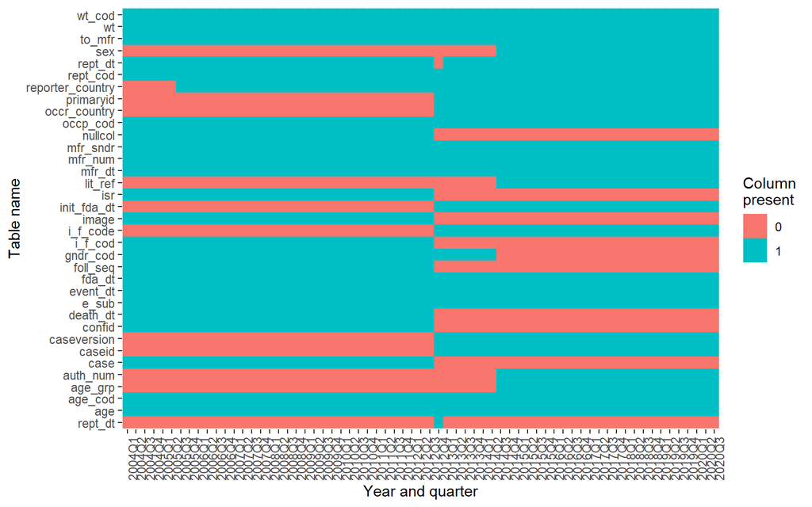

```r
summ$cols_summ %>%
  gather("year_q", "have_col", -cols) %>%
  mutate(have_col = ifelse(is.na(have_col), 0, have_col)) %>%
  ggplot(aes(year_q, cols, fill = factor(have_col))) +
    geom_tile() +
    theme(axis.text.x = element_text(angle = 90)) +
    labs(y = "Table name", x = "Year and quarter", fill = "Column\npresent")
```

### 6.3.2 DRUG table

```r
# get drug files
tab_files <- get_tab_files("drug", LOC = RAW_LOC)
```

```
## Table search string is: .*(drug|DRUG).*\.(TXT|txt)$
```

```r
(n_drug <- length(tab_files))
```

```
## [1] 67
```

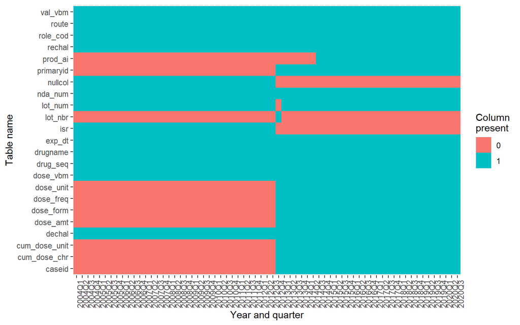

```r
# print_yr_qtr(tab_files)
summ <- get_tab_summ(tab_files, LOC = RAW_LOC)
col_present_plot(summ$cols_summ)
```

### 6.3.3 INDI table

```r
# get indi files
tab_files <- get_tab_files("indi", RAW_LOC)
```

```
## Table search string is: .*(indi|INDI).*\.(TXT|txt)$
```

```r
(n_indi <- length(tab_files))
```

```
## [1] 67
```

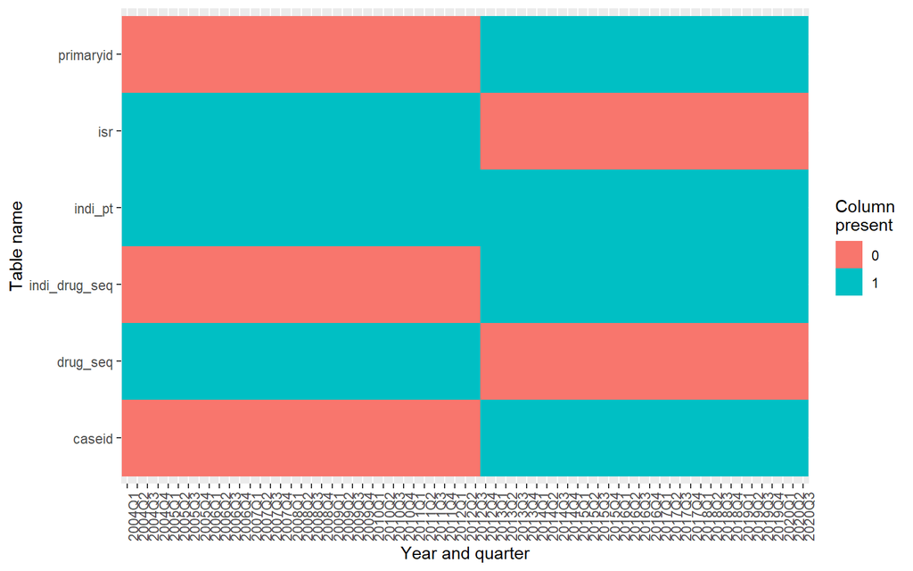

```r
# print_yr_qtr(tab_files)
summ <- get_tab_summ(tab_files, LOC = RAW_LOC)
col_present_plot(summ$cols_summ)
```

### 6.3.4 OUTC table

```r
# get outc files
tab_files <- get_tab_files("outc", RAW_LOC)
```

```
## Table search string is: .*(outc|OUTC).*\.(TXT|txt)$
```

```r
(n_outc <- length(tab_files))
```

```
## [1] 67
```

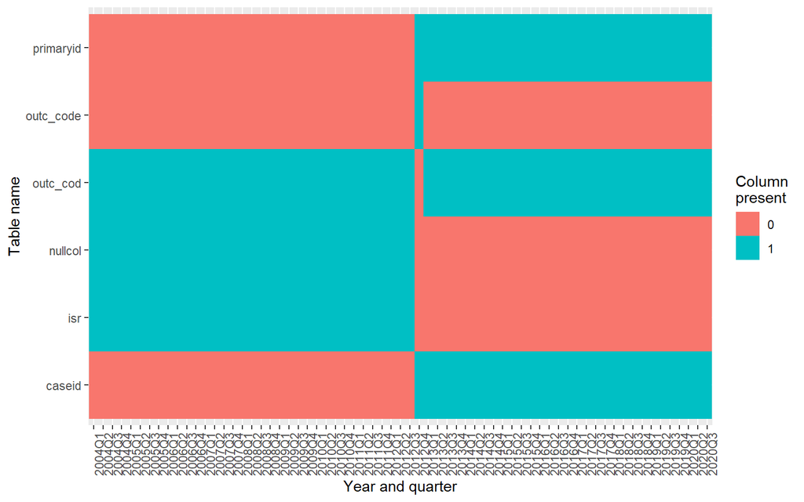

```r
# print_yr_qtr(tab_files)
summ <- get_tab_summ(tab_files, LOC = RAW_LOC)
col_present_plot(summ$cols_summ)
```

### 6.3.5 REAC table

```r
# get reac files
tab_files <- get_tab_files("reac", RAW_LOC)
```

```
## Table search string is: .*(reac|REAC).*\.(TXT|txt)$
```

```r
(n_reac <- length(tab_files))
```

```
## [1] 67
```

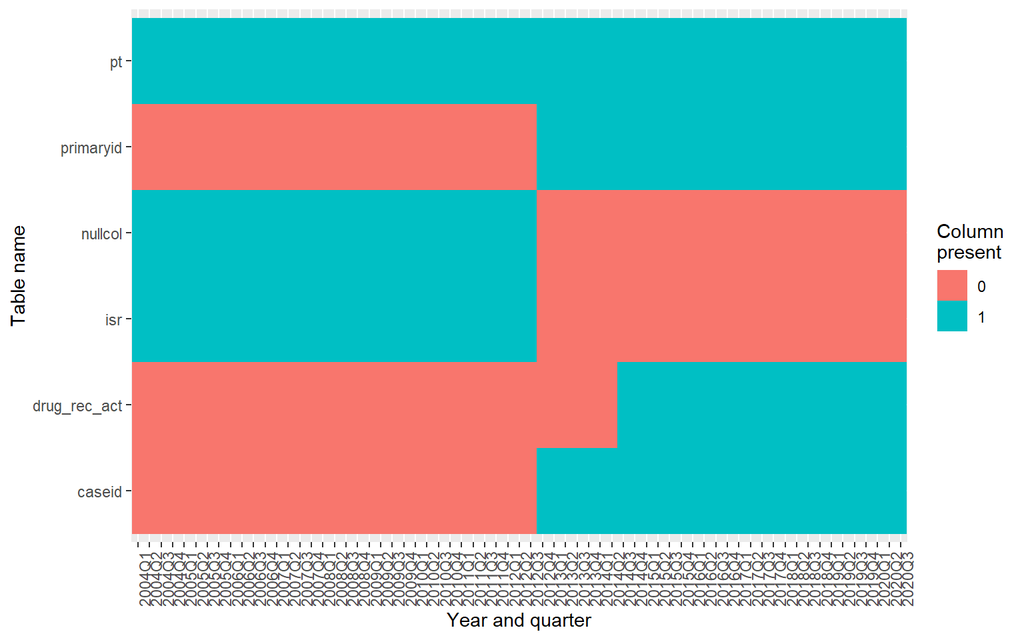

```r
# print_yr_qtr(tab_files)
summ <- get_tab_summ(tab_files, LOC = RAW_LOC)
col_present_plot(summ$cols_summ)
```

### 6.3.6 RPSR table

```r
# get rpsr files
tab_files <- get_tab_files("rpsr", RAW_LOC)
```

```
## Table search string is: .*(rpsr|RPSR).*\.(TXT|txt)$
```

```r
(n_rpsr <- length(tab_files))
```

```
## [1] 67
```

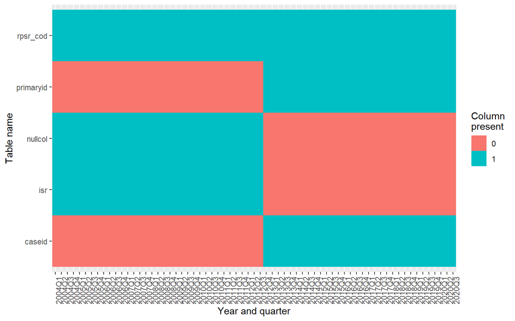

```r
# print_yr_qtr(tab_files)
summ <- get_tab_summ(tab_files, LOC = RAW_LOC)
col_present_plot(summ$cols_summ)
```

### 6.3.7 THER table

```r
# get ther files
tab_files <- get_tab_files("ther", RAW_LOC)
```

```
## Table search string is: .*(ther|THER).*\.(TXT|txt)$
```

```r
(n_ther <- length(tab_files))
```

```
## [1] 67
```

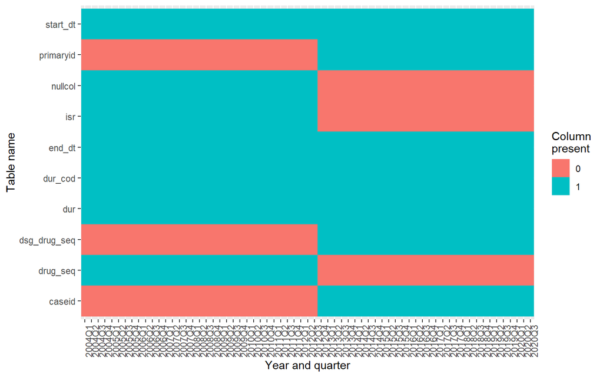

```r
# print_yr_qtr(tab_files)
summ <- get_tab_summ(tab_files, LOC = RAW_LOC)
col_present_plot(summ$cols_summ)
```

# 7 Load FAERS text files into R

The following R code imports the FAERS quarterly text file extracts for each table `demo`, `drug`, `indi`, `outc`, `reac`, `rpsr`, `ther`.

Each quarterly extract for a given table is:

- placed in a `list()` object where each element is a `tibble()` of the quarterly extract
- the list objects are then saved to storage as `xxxx_list.RData` files for processing later

In the next section, the individual quarterly extracts are flattened into a single data.frame/tibble for export.

## 7.1 DEMO tables

```r
#
# read in for real
#
demo_list <- vector(mode = "list", length = n_demo)
# table(unlist(purrr::map(demo_list, is.null)))
names(demo_list) <- paste0(years, "Q", qtrs)
for (i in 1:n_demo) {

  this_demo <-
    read_delim(
      paste0(RAW_LOC, "/", demo_files[i]),
      delim = "$",
      col_types = paste0(rep("c", summ$n_cols[i]), collapse = "")
    )
  colnames(this_demo) <- str_to_lower(colnames(this_demo))
  this_demo[["qtr"]] <- names(demo_list)[i]
  demo_list[[i]] <- this_demo

}

print_probs(demo_list)

# save list of demo tables where each element of list is a quarter's demo table
save(demo_list, file = paste0(DAT_LOC, "/demo_list.RData"))

rm(demo_list); gc() # force garbage collection after removing large R object
```

## 7.2 DRUG tables

```r
#
# read in for real
#
# save list of drug tables where each element of list is a quarter's drug table
import_qtr_data("drug", IN_LOC = RAW_LOC, OUT_LOC = DAT_LOC)
print_probs(drug_list)
head(drug_list[[n_demo]])
rm(drug_list); gc() # force garbage collection after removing large R object
```

## 7.3 INDI tables

```r
#
# read in for real
#
# save list of indi tables where each element of list is a quarter's indi table
import_qtr_data("indi", IN_LOC = RAW_LOC, OUT_LOC = DAT_LOC)
print_probs(indi_list)
head(indi_list[[n_demo]])
rm(indi_list); gc() # force garbage collection after removing large R object
```

## 7.4 OUTC tables

```r
#
# read in for real
#
# save list of outc tables where each element of list is a quarter's outc table
import_qtr_data("outc", IN_LOC = RAW_LOC, OUT_LOC = DAT_LOC)
print_probs(outc_list)
head(outc_list[[n_demo]])
rm(outc_list); gc() # force garbage collection after removing large R object
```

## 7.5 REAC tables

```r
#
# read in for real
#
# save list of reac tables where each element of list is a quarter's reac table
import_qtr_data("reac", IN_LOC = RAW_LOC, OUT_LOC = DAT_LOC)
print_probs(reac_list)
head(reac_list[[n_demo]])
rm(reac_list); gc() # force garbage collection after removing large R object
```

## 7.6 RPSR tables

```r
#
# read in for real
#
# save list of rpsr tables where each element of list is a quarter's rpsr table
import_qtr_data("rpsr", IN_LOC = RAW_LOC, OUT_LOC = DAT_LOC)
print_probs(rpsr_list)
head(rpsr_list[[n_demo]])
rm(rpsr_list); gc() # force garbage collection after removing large R object
```

## 7.7 THER tables

```r
#
# read in for real
#
# save list of ther tables where each element of list is a quarter's ther table
import_qtr_data("ther", IN_LOC = RAW_LOC, OUT_LOC = DAT_LOC)
print_probs(ther_list)
head(ther_list[[n_demo]])
rm(ther_list); gc() # force garbage collection after removing large R object
```

# 8 Turning list `.RData` files into flattened data frames

Here the list objects of quarterly extracts for each FAERS table (`xxxx_list.RData`) are restricted to quarterly extracts of 2013 onwards.

These lists objects are then:

- flattened into a single data.frame/tibble
- which are then:
  - saved as `xxxx_df.RData` and
  - output as `CSV` files ready for database/PostrgreSQL import (named `xxxx.csv`).

## 8.1 Set variables

```r
# these determine what get exported
want_rdata <- TRUE
want_csv <- TRUE
```

## 8.2 Functions to combine

```r
get_objs <- function(unit = "Mb") {
  objs <- ls(envir = .GlobalEnv)
  objs_sze <- sapply(objs, function(x) object.size(get(x)))
  objs <- objs[order(objs_sze)]
  return(
    data.frame(
      size = sapply(
        objs,
        function(x) format(object.size(get(x)), units = unit)
      )
    )
  )
}


get_rdata <- function(tab_nm, LOC = DAT_LOC) {

  t1 <- tolower(tab_nm)

  get_str <-
    paste0(
      DAT_LOC, "/", tab_nm, "_list.RData"
    )
  cat("Attempting to load file:", get_str, "\n")

  load(get_str, verbose = TRUE, envir = .GlobalEnv)

}


get_onwards_dat <- function(tab_nm, year = 2013) {

  # dat <- get(paste0(tab_nm, "_list"), envir = .GlobalEnv)
  yrs_extracted <-
    as.integer(substr(
      names(get(paste0(tab_nm, "_list"), envir = .GlobalEnv)),
    1, 4))
  kp <- yrs_extracted >= year
  assign(
    paste0(tab_nm, "_list"),
    get(paste0(tab_nm, "_list"), envir = .GlobalEnv)[kp],
    envir = .GlobalEnv
  )
  # return(dat[kp])
  return(TRUE)

}

bind_list_dfs <- function(tab_nm) {

  dat <- get(paste0(tab_nm, "_list"), envir = .GlobalEnv)
  n_quarters <- length(dat)
  cat("Attempting to bind data_frames of", n_quarters, "extracts\n")
  dat <-
    foreach(i = 1:n_quarters, .combine = bind_rows) %do% {
      dat[[i]]
    }
  assign(paste0(tab_nm, "_list"), dat, envir = .GlobalEnv)
  return(TRUE)

}


flatten_list_data <- function(tab_nm) {

  try_obj <-
    try({
      get_rdata(tab_nm)
      cat("#### Printing last 6 elements of list #####\n")
      print(tail(get(paste0(tab_nm, "_list"), envir = .GlobalEnv)))
      bool_res <- get_onwards_dat(tab_nm) # modifies the global environment objects
      if (!bool_res) stop("limiting data from 2013 onwards unsucessful")
      bool_res <- bind_list_dfs(tab_nm) # modifies the global environment objects
      if (!bool_res) stop("Flattening data unsucessful")
      cat("#### Printing last 6 lines of compressed data #####\n")
      print(tail(get(paste0(tab_nm, "_list"), envir = .GlobalEnv)))
      counts <-
        with(get(paste0(tab_nm, "_list"), envir = .GlobalEnv), table(qtr)) %>%
        as_tibble(.) %>%
        mutate(yr = substr(qtr, 1, 4))
      m_cnts <- max(counts$n)
      cnt_plot <-
        counts %>%
        ggplot(aes(qtr, n, col = yr)) +
        geom_point() +
        theme_bw() +
        theme(axis.text.x = element_text(angle = 45)) +
        ylim(0, m_cnts)
      print(cnt_plot)
      TRUE
    })

  # if (!("data.frame" %in% class(out_obj)))
  if (!(TRUE %in% try_obj))
    stop("Try-catch not completed sucessfully: error in flattening list object")

  return(TRUE)

}

max_char <- function(x) return(max(nchar(x), na.rm = TRUE))


col_info <- function(tab_nm) {
  cnms <- colnames(get(paste0(tab_nm, "_list"), envir = .GlobalEnv))
  cat("#######\n")
  sql_str <- c(paste0("CREATE TABLE faers_dat.", tab_nm, " (\n"), ");")
  sql_cols <- NULL
  for (i in 1:length(cnms)) {
    sql_tmp <- cnms[i]
    sql_tmp <-
      c(
        sql_tmp,
        max_char(get(paste0(tab_nm, "_list"), envir = .GlobalEnv)[[cnms[i]]])
      )
    sql_tmp <-
      c(
        sql_tmp,
        sum(is.na(get(paste0(tab_nm, "_list"), envir = .GlobalEnv)[[cnms[i]]]))
      )
    cat(
      "####### Max length of characters in",
      sql_tmp[1], "is",
      sql_tmp[2], "and has",
      sql_tmp[3], "NA values\n"
    )
    sql_cols <-
      c(
        sql_cols,
        paste(
          sql_tmp[1],
          ifelse(
            sql_tmp[1] %in% c("primaryid", "caseid"),
            "BIGINT",
            paste0("VARCHAR(", sql_tmp[2], ")")
          ),
          ifelse(sql_tmp[3] > 0, "NULL", "NOT NULL"),
          sep = "     "
        )
      )
  }
  cat("#######\n")
  cat(
    "####### The approximate postgres table definition is\n",
    sql_str[1], paste0(sql_cols, collapse = ",\n"), "\n", sql_str[2], "\n#######\n",
    sep = ""
  )

  return(TRUE)
}


export_data <- function(tab_nm, save_rdata = FALSE, save_csv = FALSE) {

  bool_res <- flatten_list_data(tab_nm)
  if (!bool_res) stop("flatten_list_data(...) unsucessful")
  col_info(tab_nm)
  if (save_rdata) {
    save(
      list = paste0(tab_nm, "_list"),
      file = paste0(DAT_LOC, "/", tab_nm, "_df.RData")
    )
  }
  if (save_csv) {
    write_csv(
      get(paste0(tab_nm, "_list"), envir = .GlobalEnv),
      path = paste0(CSV_LOC, "/", tab_nm, ".csv"),
      na = ""
    )
  }
  cat(
    "Removing", paste0(tab_nm, "_list"),
    "from the global environment to free up memory...\n"
  )
  rm(list = paste0(tab_nm, "_list"), envir = .GlobalEnv)
  # cat(
  #   "These are the objects in the global environment",
  #   "before returning from export_data():\n"
  # )
  # print(get_objs())

  return(TRUE)

}

# see how the memory is going...
# get_objs()
```

## 8.3 DEMO data

```r
################ demo data ################

export_data("demo", want_rdata, want_csv)
```

```
## Attempting to load file: C:/Users/Public/faers/rdat/demo_list.RData
## Loading objects:
##   demo_list
## #### Printing last 6 elements of list #####
## $`2019Q2`
## # A tibble: 441,109 x 26
##    primaryid caseid caseversion i_f_code event_dt mfr_dt init_fda_dt fda_dt
##    <chr>     <chr>  <chr>       <chr>    <chr>    <chr>  <chr>       <chr>
##  1 10006618~ 10006~ 13          F        <NA>     20190~ 20140313    20190~
##  2 10008084~ 10008~ 10          F        <NA>     20190~ 20140313    20190~
##  3 100088884 10008~ 4           F        2012     20190~ 20140312    20190~
##  4 100097843 10009~ 3           F        201212   20190~ 20140312    20190~
##  5 10011639~ 10011~ 24          F        2015     20190~ 20140314    20190~
##  6 10014432~ 10014~ 22          F        <NA>     20190~ 20140317    20190~
##  7 100146142 10014~ 2           F        20040103 20190~ 20140317    20190~
##  8 100146452 10014~ 2           F        20111207 20190~ 20140317    20190~
##  9 100156664 10015~ 4           F        <NA>     20190~ 20140317    20190~
## 10 100162563 10016~ 3           F        20140305 20190~ 20140317    20190~
## # ... with 441,099 more rows, and 18 more variables: rept_cod <chr>,
## #   auth_num <chr>, mfr_num <chr>, mfr_sndr <chr>, lit_ref <chr>, age <chr>,
## #   age_cod <chr>, age_grp <chr>, sex <chr>, e_sub <chr>, wt <chr>,
## #   wt_cod <chr>, rept_dt <chr>, to_mfr <chr>, occp_cod <chr>,
## #   reporter_country <chr>, occr_country <chr>, qtr <chr>
##
## $`2019Q3`
## # A tibble: 452,873 x 26
##    primaryid caseid caseversion i_f_code event_dt mfr_dt init_fda_dt fda_dt
##    <chr>     <chr>  <chr>       <chr>    <chr>    <chr>  <chr>       <chr>
##  1 100055462 10005~ 2           F        20140305 20190~ 20140313    20190~
##  2 100066474 10006~ 4           F        <NA>     20190~ 20140313    20190~
##  3 100095093 10009~ 3           F        2012     20190~ 20140312    20190~
##  4 100101023 10010~ 3           F        201212   20190~ 20140312    20190~
##  5 10010901~ 10010~ 13          F        2011     20190~ 20140314    20190~
##  6 10011639~ 10011~ 25          F        2015     20190~ 20140314    20190~
##  7 100133433 10013~ 3           F        <NA>     20190~ 20140314    20190~
##  8 100133442 10013~ 2           F        <NA>     20190~ 20140314    20190~
##  9 100146416 10014~ 6           F        20140204 20190~ 20140317    20190~
## 10 100146453 10014~ 3           F        2011     20190~ 20140317    20190~
## # ... with 452,863 more rows, and 18 more variables: rept_cod <chr>,
## #   auth_num <chr>, mfr_num <chr>, mfr_sndr <chr>, lit_ref <chr>, age <chr>,
```

[output cut: 85 more lines]

```
## #### Printing last 6 lines of compressed data #####
## # A tibble: 6 x 27
##   primaryid caseid caseversion i_f_code event_dt mfr_dt init_fda_dt fda_dt
##   <chr>     <chr>  <chr>       <chr>    <chr>    <chr>  <chr>       <chr>
## 1 99983421  99983~ 1           I        20091021 20140~ 20140312    20140~
## 2 99988814  99988~ 4           F        20140116 20200~ 20140312    20200~
## 3 99988881  99988~ 1           I        2012     20140~ 20140312    20140~
## 4 99989772  99989~ 2           F        20101122 20140~ 20140312    20140~
## 5 99990442  99990~ 2           F        20100122 20140~ 20140312    20140~
## 6 999913118 99991~ 18          F        20120823 20200~ 20140312    20200~
## # ... with 19 more variables: rept_cod <chr>, mfr_num <chr>, mfr_sndr <chr>,
## #   age <chr>, age_cod <chr>, gndr_cod <chr>, e_sub <chr>, wt <chr>,
## #   wt_cod <chr>, rept_dt <chr>, to_mfr <chr>, occp_cod <chr>,
## #   reporter_country <chr>, occr_country <chr>, qtr <chr>, auth_num <chr>,
## #   lit_ref <chr>, age_grp <chr>, sex <chr>
```

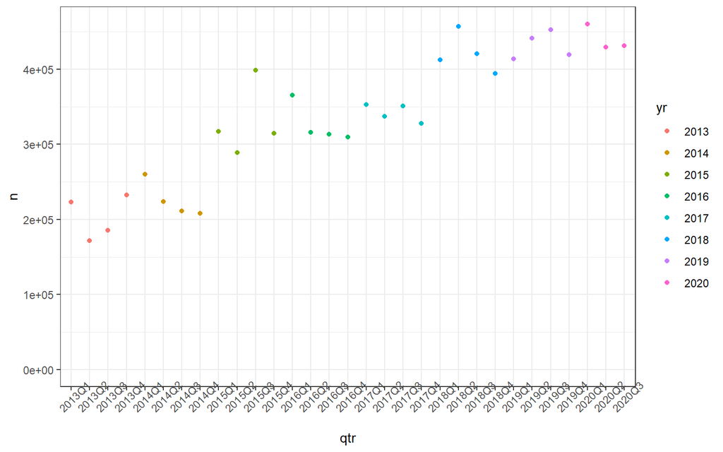

```
## #######
## ####### Max length of characters in primaryid is 11 and has 0 NA values
## ####### Max length of characters in caseid is 8 and has 0 NA values
## ####### Max length of characters in caseversion is 3 and has 0 NA values
## ####### Max length of characters in i_f_code is 1 and has 0 NA values
## ####### Max length of characters in event_dt is 8 and has 5114047 NA values
## ####### Max length of characters in mfr_dt is 8 and has 471171 NA values
## ####### Max length of characters in init_fda_dt is 8 and has 0 NA values
## ####### Max length of characters in fda_dt is 8 and has 0 NA values
## ####### Max length of characters in rept_cod is 5 and has 10 NA values
## ####### Max length of characters in mfr_num is 89 and has 470677 NA values
## ####### Max length of characters in mfr_sndr is 65 and has 139715 NA values
## ####### Max length of characters in age is 7 and has 4394603 NA values
## ####### Max length of characters in age_cod is 3 and has 4402822 NA values
## ####### Max length of characters in gndr_cod is 3 and has 9146979 NA values
## ####### Max length of characters in e_sub is 1 and has 0 NA values
## ####### Max length of characters in wt is 7 and has 8336068 NA values
## ####### Max length of characters in wt_cod is 5 and has 8336655 NA values
## ####### Max length of characters in rept_dt is 8 and has 8761 NA values
## ####### Max length of characters in to_mfr is 1 and has 8172056 NA values
## ####### Max length of characters in occp_cod is 5 and has 294621 NA values
## ####### Max length of characters in reporter_country is 21 and has 52 NA values
## ####### Max length of characters in occr_country is 2 and has 311700 NA values
## ####### Max length of characters in qtr is 6 and has 0 NA values
## ####### Max length of characters in auth_num is 100 and has 10060514 NA values
## ####### Max length of characters in lit_ref is 500 and has 9974596 NA values
## ####### Max length of characters in age_grp is 1 and has 8781327 NA values
## ####### Max length of characters in sex is 3 and has 2422477 NA values
## #######
## ####### The approximate postgres table definition is
## CREATE TABLE faers_dat.demo (
## primaryid     BIGINT     NOT NULL,
## caseid     BIGINT     NOT NULL,
## caseversion     VARCHAR(3)     NOT NULL,
## i_f_code     VARCHAR(1)     NOT NULL,
## event_dt     VARCHAR(8)     NULL,
## mfr_dt     VARCHAR(8)     NULL,
## init_fda_dt     VARCHAR(8)     NOT NULL,
## fda_dt     VARCHAR(8)     NOT NULL,
## rept_cod     VARCHAR(5)     NULL,
## mfr_num     VARCHAR(89)     NULL,
## mfr_sndr     VARCHAR(65)     NULL,
## age     VARCHAR(7)     NULL,
## age_cod     VARCHAR(3)     NULL,
## gndr_cod     VARCHAR(3)     NULL,
## e_sub     VARCHAR(1)     NOT NULL,
## wt     VARCHAR(7)     NULL,
## wt_cod     VARCHAR(5)     NULL,
## rept_dt     VARCHAR(8)     NULL,
## to_mfr     VARCHAR(1)     NULL,
## occp_cod     VARCHAR(5)     NULL,
## reporter_country     VARCHAR(21)     NULL,
## occr_country     VARCHAR(2)     NULL,
## qtr     VARCHAR(6)     NOT NULL,
## auth_num     VARCHAR(100)     NULL,
## lit_ref     VARCHAR(500)     NULL,
## age_grp     VARCHAR(1)     NULL,
## sex     VARCHAR(3)     NULL
## );
## #######
## Removing demo_list from the global environment to free up memory...
```

```
## [1] TRUE
```

## 8.4 DRUG data

```r
################ drug data ################

export_data("drug", want_rdata, want_csv)
```

```
## Attempting to load file: C:/Users/Public/faers/rdat/drug_list.RData
## Loading objects:
##   drug_list
## #### Printing last 6 elements of list #####
## $`2019Q2`
## # A tibble: 1,863,012 x 21
##    primaryid caseid drug_seq role_cod drugname prod_ai val_vbm route dose_vbm
##    <chr>     <chr>  <chr>    <chr>    <chr>    <chr>   <chr>   <chr> <chr>
##  1 10006618~ 10006~ 1        PS       LIPITOR  ATORVA~ 1       <NA>  UNK
##  2 10006618~ 10006~ 2        SS       BENTYL   DICYCL~ 1       <NA>  UNK
##  3 10006618~ 10006~ 3        SS       DICYCLO~ DICYCL~ 1       <NA>  UNK
##  4 10008084~ 10008~ 1        PS       INFLIXI~ INFLIX~ 1       Intr~ <NA>
##  5 10008084~ 10008~ 2        C        METHOTR~ METHOT~ 1       Unkn~ <NA>
##  6 100088884 10008~ 1        PS       JAKAFI   RUXOLI~ 1       Oral  20 MG, ~
##  7 100088884 10008~ 2        SS       JAKAFI   RUXOLI~ 1       Oral  10 MG, ~
##  8 100088884 10008~ 3        SS       JAKAFI   RUXOLI~ 1       Oral  10 MG, ~
##  9 100088884 10008~ 4        SS       JAKAFI   RUXOLI~ 1       Oral  5 MG, B~
## 10 100088884 10008~ 5        SS       JAKAFI   RUXOLI~ 1       Oral  10MG QA~
## # ... with 1,863,002 more rows, and 12 more variables: cum_dose_chr <chr>,
## #   cum_dose_unit <chr>, dechal <chr>, rechal <chr>, lot_num <chr>,
## #   exp_dt <chr>, nda_num <chr>, dose_amt <chr>, dose_unit <chr>,
## #   dose_form <chr>, dose_freq <chr>, qtr <chr>
##
## $`2019Q3`
## # A tibble: 1,982,442 x 21
##    primaryid caseid drug_seq role_cod drugname prod_ai val_vbm route dose_vbm
##    <chr>     <chr>  <chr>    <chr>    <chr>    <chr>   <chr>   <chr> <chr>
##  1 100055462 10005~ 1        PS       ACTEMRA  TOCILI~ 1       Intr~ <NA>
##  2 100055462 10005~ 2        SS       ACTEMRA  TOCILI~ 1       Intr~ <NA>
##  3 100066474 10006~ 1        PS       MORPHIN~ MORPHI~ 1       <NA>  UNK
##  4 100095093 10009~ 1        PS       JAKAFI   RUXOLI~ 1       Oral  15 MILL~
##  5 100095093 10009~ 2        SS       JAKAFI   RUXOLI~ 1       Oral  5 MILLI~
##  6 100095093 10009~ 3        SS       JAKAFI   RUXOLI~ 1       Oral  10 MILL~
##  7 100101023 10010~ 1        PS       JAKAFI   RUXOLI~ 1       Oral  20 MILL~
##  8 100101023 10010~ 2        SS       JAKAFI   RUXOLI~ 1       Oral  15 MILL~
##  9 100101023 10010~ 3        SS       JAKAFI   RUXOLI~ 1       Oral  15 MILL~
## 10 10010901~ 10010~ 1        PS       PREZISTA DARUNA~ 1       Oral  <NA>
## # ... with 1,982,432 more rows, and 12 more variables: cum_dose_chr <chr>,
## #   cum_dose_unit <chr>, dechal <chr>, rechal <chr>, lot_num <chr>,
## #   exp_dt <chr>, nda_num <chr>, dose_amt <chr>, dose_unit <chr>,
```

[output cut: 78 more lines]

```
## Attempting to bind data_frames of 31 extracts
## #### Printing last 6 lines of compressed data #####
## # A tibble: 6 x 21
##   primaryid caseid drug_seq role_cod drugname val_vbm route dose_vbm
##   <chr>     <chr>  <chr>    <chr>    <chr>    <chr>   <chr> <chr>
## 1 999913118 99991~ 7        C        IMIQUIM~ 1       Unkn~ <NA>
## 2 999913118 99991~ 8        C        IMIQUIM~ 1       Unkn~ <NA>
## 3 999913118 99991~ 9        C        TESTOST~ 1       Unkn~ <NA>
## 4 999913118 99991~ 10       C        GARLIC.  1       Unkn~ <NA>
## 5 999913118 99991~ 11       C        CLOBETA~ 1       Unkn~ <NA>
## 6 999913118 99991~ 12       C        SORIATA~ 1       Unkn~ <NA>
## # ... with 13 more variables: cum_dose_chr <chr>, cum_dose_unit <chr>,
## #   dechal <chr>, rechal <chr>, lot_num <chr>, exp_dt <chr>, nda_num <chr>,
## #   dose_amt <chr>, dose_unit <chr>, dose_form <chr>, dose_freq <chr>,
## #   qtr <chr>, prod_ai <chr>
```

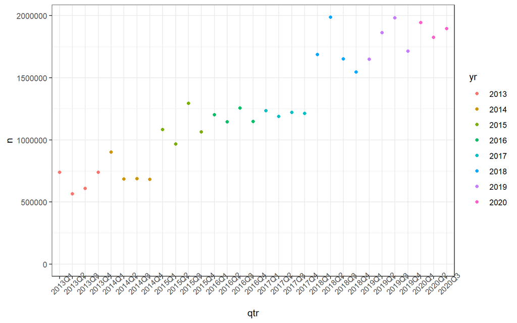

```
## #######
## ####### Max length of characters in primaryid is 11 and has 0 NA values
## ####### Max length of characters in caseid is 8 and has 0 NA values
## ####### Max length of characters in drug_seq is 3 and has 0 NA values
## ####### Max length of characters in role_cod is 2 and has 4 NA values
## ####### Max length of characters in drugname is 500 and has 39 NA values
## ####### Max length of characters in val_vbm is 1 and has 0 NA values
## ####### Max length of characters in route is 37 and has 12442254 NA values
## ####### Max length of characters in dose_vbm is 288 and has 18433451 NA values
## ####### Max length of characters in cum_dose_chr is 15 and has 38395927 NA values
## ####### Max length of characters in cum_dose_unit is 8 and has 38397557 NA values
## ####### Max length of characters in dechal is 1 and has 25656492 NA values
## ####### Max length of characters in rechal is 2 and has 25768656 NA values
## ####### Max length of characters in lot_num is 363 and has 33086893 NA values
## ####### Max length of characters in exp_dt is 139 and has 39229187 NA values
## ####### Max length of characters in nda_num is 27 and has 25784540 NA values
## ####### Max length of characters in dose_amt is 15 and has 22843909 NA values
## ####### Max length of characters in dose_unit is 10 and has 22849442 NA values
## ####### Max length of characters in dose_form is 50 and has 21770225 NA values
## ####### Max length of characters in dose_freq is 11 and has 28709767 NA values
## ####### Max length of characters in qtr is 6 and has 0 NA values
## ####### Max length of characters in prod_ai is 300 and has 5051411 NA values
## #######
## ####### The approximate postgres table definition is
## CREATE TABLE faers_dat.drug (
## primaryid     BIGINT     NOT NULL,
## caseid     BIGINT     NOT NULL,
## drug_seq     VARCHAR(3)     NOT NULL,
## role_cod     VARCHAR(2)     NULL,
## drugname     VARCHAR(500)     NULL,
## val_vbm     VARCHAR(1)     NOT NULL,
## route     VARCHAR(37)     NULL,
## dose_vbm     VARCHAR(288)     NULL,
## cum_dose_chr     VARCHAR(15)     NULL,
## cum_dose_unit     VARCHAR(8)     NULL,
## dechal     VARCHAR(1)     NULL,
## rechal     VARCHAR(2)     NULL,
## lot_num     VARCHAR(363)     NULL,
## exp_dt     VARCHAR(139)     NULL,
## nda_num     VARCHAR(27)     NULL,
## dose_amt     VARCHAR(15)     NULL,
## dose_unit     VARCHAR(10)     NULL,
## dose_form     VARCHAR(50)     NULL,
## dose_freq     VARCHAR(11)     NULL,
## qtr     VARCHAR(6)     NOT NULL,
## prod_ai     VARCHAR(300)     NULL
## );
## #######
## Removing drug_list from the global environment to free up memory...
```

```
## [1] TRUE
```

## 8.5 INDI data

```r
################ indi data ################

export_data("indi", want_rdata, want_csv)
```

```
## Attempting to load file: C:/Users/Public/faers/rdat/indi_list.RData
## Loading objects:
##   indi_list
## #### Printing last 6 elements of list #####
## $`2019Q2`
## # A tibble: 1,221,164 x 5
##    primaryid  caseid   indi_drug_seq indi_pt                             qtr
##    <chr>      <chr>    <chr>         <chr>                               <chr>
##  1 1000808410 10008084 1             Rheumatoid arthritis                2019Q2
##  2 100088884  10008888 1             Myelofibrosis                       2019Q2
##  3 100088884  10008888 7             Product used for unknown indication 2019Q2
##  4 100088884  10008888 8             Product used for unknown indication 2019Q2
##  5 100088884  10008888 9             Product used for unknown indication 2019Q2
##  6 100088884  10008888 10            Product used for unknown indication 2019Q2
##  7 100088884  10008888 11            Product used for unknown indication 2019Q2
##  8 100097843  10009784 1             Myelofibrosis                       2019Q2
##  9 100097843  10009784 3             Gastric disorder                    2019Q2
## 10 100097843  10009784 4             Product used for unknown indication 2019Q2
## # ... with 1,221,154 more rows
##
## $`2019Q3`
## # A tibble: 1,353,011 x 5
##    primaryid  caseid   indi_drug_seq indi_pt                          qtr
##    <chr>      <chr>    <chr>         <chr>                            <chr>
##  1 100055462  10005546 1             Rheumatoid arthritis             2019Q3
##  2 100066474  10006647 1             Procedural pain                  2019Q3
##  3 100095093  10009509 1             Myelofibrosis                    2019Q3
##  4 100101023  10010102 1             Myelofibrosis                    2019Q3
##  5 1001090113 10010901 1             HIV infection                    2019Q3
##  6 1001090113 10010901 2             Cytomegalovirus infection        2019Q3
##  7 1001090113 10010901 9             Prophylaxis                      2019Q3
##  8 1001090113 10010901 10            Atypical mycobacterial infection 2019Q3
##  9 1001090113 10010901 12            Atypical mycobacterial infection 2019Q3
## 10 1001090113 10010901 13            Antifungal prophylaxis           2019Q3
## # ... with 1,353,001 more rows
##
## $`2019Q4`
## # A tibble: 1,146,938 x 5
##    primaryid caseid   indi_drug_seq indi_pt                           qtr
##    <chr>     <chr>    <chr>         <chr>                             <chr>
```

[output cut: 56 more lines]

```
##  9 100049343 10004934 3             Blood cholesterol increased       2020Q3
## 10 100049343 10004934 4             Blood cholesterol increased       2020Q3
## # ... with 1,276,338 more rows
##
## Attempting to bind data_frames of 31 extracts
## #### Printing last 6 lines of compressed data #####
## # A tibble: 6 x 5
##   primaryid caseid  indi_drug_seq indi_pt                               qtr
##   <chr>     <chr>   <chr>         <chr>                                 <chr>
## 1 99988814  9998881 3             Product used for unknown indication   2020Q3
## 2 99988814  9998881 5             Peripheral arterial occlusive disease 2020Q3
## 3 99988881  9998888 1             Osteoporosis                          2020Q3
## 4 99989772  9998977 1             Cancer pain                           2020Q3
## 5 99990442  9999044 1             Breast cancer metastatic              2020Q3
## 6 999913118 9999131 1             Psoriasis                             2020Q3
```

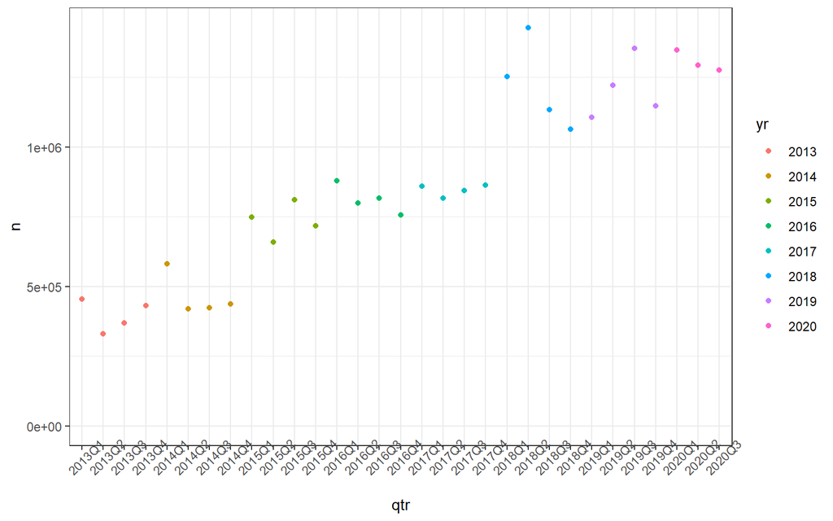

```
## #######
## ####### Max length of characters in primaryid is 11 and has 0 NA values
## ####### Max length of characters in caseid is 8 and has 0 NA values
## ####### Max length of characters in indi_drug_seq is 3 and has 0 NA values
## ####### Max length of characters in indi_pt is 93 and has 0 NA values
## ####### Max length of characters in qtr is 6 and has 0 NA values
## #######
## ####### The approximate postgres table definition is
## CREATE TABLE faers_dat.indi (
## primaryid     BIGINT     NOT NULL,
## caseid     BIGINT     NOT NULL,
## indi_drug_seq     VARCHAR(3)     NOT NULL,
## indi_pt     VARCHAR(93)     NOT NULL,
## qtr     VARCHAR(6)     NOT NULL
## );
## #######
## Removing indi_list from the global environment to free up memory...
```

```
## [1] TRUE
```

## 8.6 OUTC data

```r
################ outc data ################

export_data("outc", want_rdata, want_csv)
```

```
## Attempting to load file: C:/Users/Public/faers/rdat/outc_list.RData
## Loading objects:
##   outc_list
## #### Printing last 6 elements of list #####
## $`2019Q2`
## # A tibble: 324,739 x 4
##    primaryid  caseid   outc_cod qtr
##    <chr>      <chr>    <chr>    <chr>
##  1 1000808410 10008084 OT       2019Q2
##  2 100088884  10008888 OT       2019Q2
##  3 100097843  10009784 OT       2019Q2
##  4 1001163924 10011639 OT       2019Q2
##  5 1001443222 10014432 HO       2019Q2
##  6 1001443222 10014432 OT       2019Q2
##  7 100146142  10014614 CA       2019Q2
##  8 100146452  10014645 DE       2019Q2
##  9 100162563  10016256 HO       2019Q2
## 10 1001721434 10017214 OT       2019Q2
## # ... with 324,729 more rows
##
## $`2019Q3`
## # A tibble: 323,787 x 4
##    primaryid  caseid   outc_cod qtr
##    <chr>      <chr>    <chr>    <chr>
##  1 100055462  10005546 OT       2019Q3
##  2 100055462  10005546 HO       2019Q3
##  3 100066474  10006647 HO       2019Q3
##  4 100095093  10009509 HO       2019Q3
##  5 1001090113 10010901 HO       2019Q3
##  6 1001090113 10010901 OT       2019Q3
##  7 1001163925 10011639 OT       2019Q3
##  8 100146416  10014641 HO       2019Q3
##  9 100146416  10014641 OT       2019Q3
## 10 100146416  10014641 DE       2019Q3
## # ... with 323,777 more rows
##
## $`2019Q4`
## # A tibble: 321,603 x 4
##    primaryid caseid   outc_cod qtr
##    <chr>     <chr>    <chr>    <chr>
```

[output cut: 56 more lines]

```
##  9 100084551 10008455 OT       2020Q3
## 10 100089542 10008954 OT       2020Q3
## # ... with 358,805 more rows
##
## Attempting to bind data_frames of 31 extracts
## #### Printing last 6 lines of compressed data #####
## # A tibble: 6 x 4
##   primaryid caseid  outc_cod qtr
##   <chr>     <chr>   <chr>    <chr>
## 1 99988814  9998881 HO       2020Q3
## 2 99988814  9998881 DE       2020Q3
## 3 99988881  9998888 OT       2020Q3
## 4 99989772  9998977 OT       2020Q3
## 5 99989772  9998977 HO       2020Q3
## 6 99990442  9999044 HO       2020Q3
```

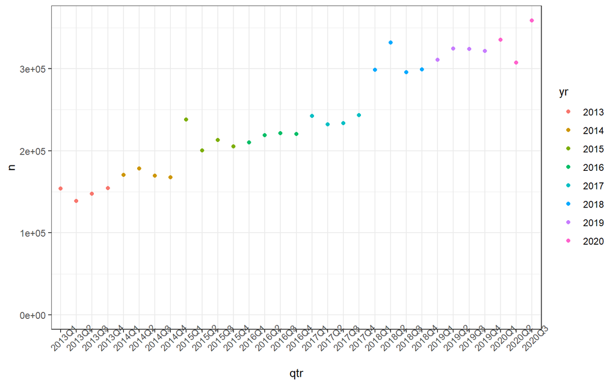

```
## #######
## ####### Max length of characters in primaryid is 11 and has 0 NA values
## ####### Max length of characters in caseid is 8 and has 0 NA values
## ####### Max length of characters in outc_cod is 2 and has 0 NA values
## ####### Max length of characters in qtr is 6 and has 0 NA values
## #######
## ####### The approximate postgres table definition is
## CREATE TABLE faers_dat.outc (
## primaryid     BIGINT     NOT NULL,
## caseid     BIGINT     NOT NULL,
## outc_cod     VARCHAR(2)     NOT NULL,
## qtr     VARCHAR(6)     NOT NULL
## );
## #######
## Removing outc_list from the global environment to free up memory...
```

```
## [1] TRUE
```

## 8.7 REAC data

```r
################ reac data ################

export_data("reac", want_rdata, want_csv)
```

```
## Attempting to load file: C:/Users/Public/faers/rdat/reac_list.RData
## Loading objects:
##   reac_list
## #### Printing last 6 elements of list #####
## $`2019Q2`
## # A tibble: 1,408,486 x 5
##    primaryid  caseid   pt                                    drug_rec_act qtr
##    <chr>      <chr>    <chr>                                 <chr>        <chr>
##  1 1000661813 10006618 Drug hypersensitivity                 <NA>         2019Q2
##  2 1000661813 10006618 Muscular weakness                     <NA>         2019Q2
##  3 1000661813 10006618 Rash                                  <NA>         2019Q2
##  4 1000661813 10006618 Urticaria                             <NA>         2019Q2
##  5 1000808410 10008084 Adverse event                         <NA>         2019Q2
##  6 1000808410 10008084 Antinuclear antibody positive         <NA>         2019Q2
##  7 1000808410 10008084 Autoantibody positive                 <NA>         2019Q2
##  8 1000808410 10008084 Autoimmune disorder                   <NA>         2019Q2
##  9 1000808410 10008084 Double stranded DNA antibody positive <NA>         2019Q2
## 10 1000808410 10008084 Infection                             <NA>         2019Q2
## # ... with 1,408,476 more rows
##
## $`2019Q3`
## # A tibble: 1,504,790 x 5
##    primaryid caseid   pt                           drug_rec_act qtr
##    <chr>     <chr>    <chr>                        <chr>        <chr>
##  1 100055462 10005546 Blood potassium decreased    <NA>         2019Q3
##  2 100055462 10005546 Diverticulitis               <NA>         2019Q3
##  3 100055462 10005546 Gastrointestinal haemorrhage <NA>         2019Q3
##  4 100055462 10005546 Haemorrhoids                 <NA>         2019Q3
##  5 100066474 10006647 Dizziness                    <NA>         2019Q3
##  6 100066474 10006647 Drug hypersensitivity        <NA>         2019Q3
##  7 100066474 10006647 Hypoaesthesia                <NA>         2019Q3
##  8 100095093 10009509 Anaemia                      <NA>         2019Q3
##  9 100095093 10009509 Blood count abnormal         <NA>         2019Q3
## 10 100101023 10010102 Alopecia                     <NA>         2019Q3
## # ... with 1,504,780 more rows
##
## $`2019Q4`
## # A tibble: 1,359,922 x 5
##    primaryid caseid   pt                         drug_rec_act qtr
##    <chr>     <chr>    <chr>                      <chr>        <chr>
```

[output cut: 56 more lines]

```
##  9 100084551 10008455 Hypokalaemia             <NA>         2020Q3
## 10 100084551 10008455 Hypophosphataemia        <NA>         2020Q3
## # ... with 1,454,034 more rows
##
## Attempting to bind data_frames of 31 extracts
## #### Printing last 6 lines of compressed data #####
## # A tibble: 6 x 5
##   primaryid caseid  pt                       qtr    drug_rec_act
##   <chr>     <chr>   <chr>                    <chr>  <chr>
## 1 99988814  9998881 Pain                     2020Q3 <NA>
## 2 99988881  9998888 Malignant melanoma       2020Q3 <NA>
## 3 99989772  9998977 Renal failure            2020Q3 <NA>
## 4 99990442  9999044 Subarachnoid haemorrhage 2020Q3 <NA>
## 5 999913118 9999131 Basal cell carcinoma     2020Q3 <NA>
## 6 999913118 9999131 Squamous cell carcinoma  2020Q3 <NA>
```

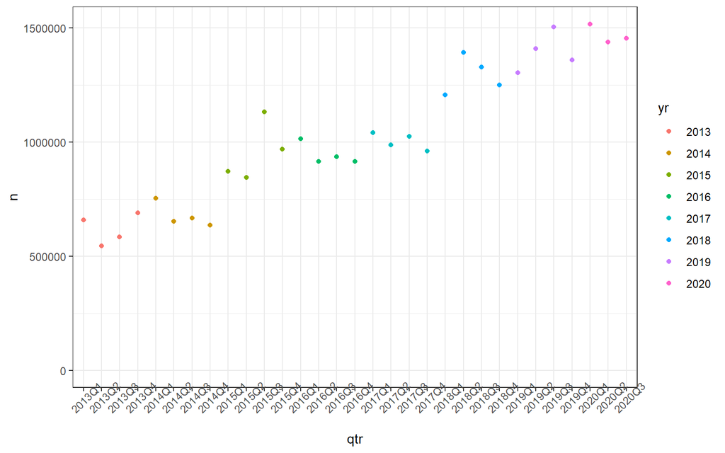

```
## #######
## ####### Max length of characters in primaryid is 11 and has 0 NA values
## ####### Max length of characters in caseid is 8 and has 0 NA values
## ####### Max length of characters in pt is 93 and has 0 NA values
## ####### Max length of characters in qtr is 6 and has 0 NA values
## ####### Max length of characters in drug_rec_act is 66 and has 31903409 NA values
## #######
## ####### The approximate postgres table definition is
## CREATE TABLE faers_dat.reac (
## primaryid     BIGINT     NOT NULL,
## caseid     BIGINT     NOT NULL,
## pt     VARCHAR(93)     NOT NULL,
## qtr     VARCHAR(6)     NOT NULL,
## drug_rec_act     VARCHAR(66)     NULL
## );
## #######
## Removing reac_list from the global environment to free up memory...
```

```
## [1] TRUE
```

## 8.8 RPSR data

```r
################ rpsr data ################

export_data("rpsr", want_rdata, want_csv)
```

```
## Attempting to load file: C:/Users/Public/faers/rdat/rpsr_list.RData
## Loading objects:
##   rpsr_list
## #### Printing last 6 elements of list #####
## $`2019Q2`
## # A tibble: 23,644 x 4
##    primaryid caseid   rpsr_cod qtr
##    <chr>     <chr>    <chr>    <chr>
##  1 158794141 15879414 HP       2019Q2
##  2 160163941 16016394 CSM      2019Q2
##  3 160163961 16016396 CSM      2019Q2
##  4 160164251 16016425 HP       2019Q2
##  5 160164981 16016498 HP       2019Q2
##  6 160175441 16017544 HP       2019Q2
##  7 160175671 16017567 HP       2019Q2
##  8 160175761 16017576 CSM      2019Q2
##  9 160176641 16017664 HP       2019Q2
## 10 160176711 16017671 HP       2019Q2
## # ... with 23,634 more rows
##
## $`2019Q3`
## # A tibble: 20,652 x 4
##    primaryid caseid   rpsr_cod qtr
##    <chr>     <chr>    <chr>    <chr>
##  1 163418851 16341885 CSM      2019Q3
##  2 163420011 16342001 CSM      2019Q3
##  3 163420511 16342051 CSM      2019Q3
##  4 163420611 16342061 CSM      2019Q3
##  5 163421911 16342191 CSM      2019Q3
##  6 163422171 16342217 CSM      2019Q3
##  7 163428311 16342831 CSM      2019Q3
##  8 163428601 16342860 HP       2019Q3
##  9 163428931 16342893 HP       2019Q3
## 10 163429161 16342916 CSM      2019Q3
## # ... with 20,642 more rows
##
## $`2019Q4`
## # A tibble: 23,774 x 4
##    primaryid caseid   rpsr_cod qtr
##    <chr>     <chr>    <chr>    <chr>
```

[output cut: 56 more lines]

```
##  9 109456491 10945649 FGN      2020Q3
## 10 110247991 11024799 HP       2020Q3
## # ... with 17,271 more rows
##
## Attempting to bind data_frames of 31 extracts
## #### Printing last 6 lines of compressed data #####
## # A tibble: 6 x 4
##   primaryid caseid  rpsr_cod qtr
##   <chr>     <chr>   <chr>    <chr>
## 1 97273471  9727347 FGN      2020Q3
## 2 98220351  9822035 FGN      2020Q3
## 3 98443951  9844395 LIT      2020Q3
## 4 98443951  9844395 HP       2020Q3
## 5 98443951  9844395 FGN      2020Q3
## 6 99816691  9981669 HP       2020Q3
```

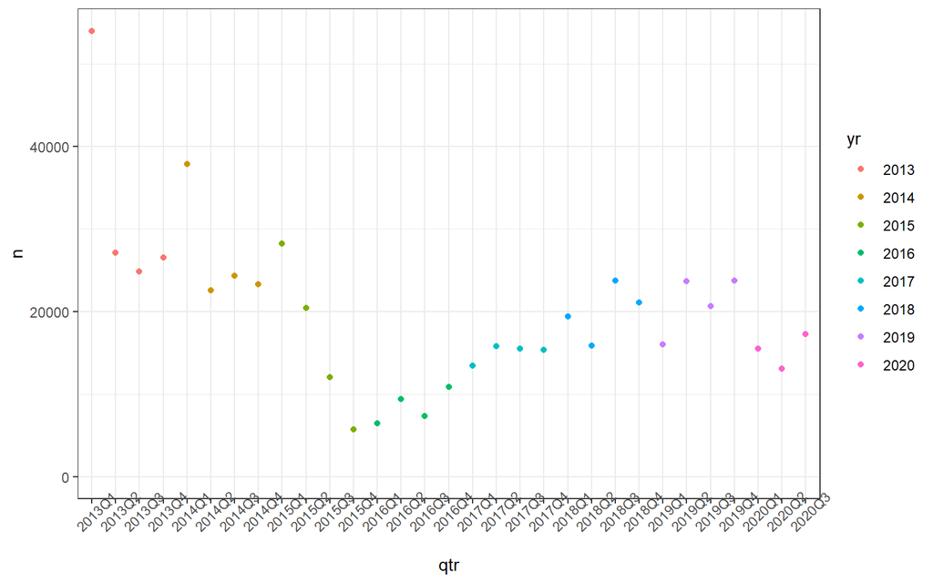

```
## #######
## ####### Max length of characters in primaryid is 10 and has 0 NA values
## ####### Max length of characters in caseid is 8 and has 0 NA values
## ####### Max length of characters in rpsr_cod is 3 and has 0 NA values
## ####### Max length of characters in qtr is 6 and has 0 NA values
## #######
## ####### The approximate postgres table definition is
## CREATE TABLE faers_dat.rpsr (
## primaryid     BIGINT     NOT NULL,
## caseid     BIGINT     NOT NULL,
## rpsr_cod     VARCHAR(3)     NOT NULL,
## qtr     VARCHAR(6)     NOT NULL
## );
## #######
## Removing rpsr_list from the global environment to free up memory...
```

```
## [1] TRUE
```

## 8.9 THER data

```r
################ ther data ################

export_data("ther", want_rdata, want_csv)
```

```
## Attempting to load file: C:/Users/Public/faers/rdat/ther_list.RData
## Loading objects:
##   ther_list
## #### Printing last 6 elements of list #####
## $`2019Q2`
## # A tibble: 747,537 x 8
##    primaryid  caseid   dsg_drug_seq start_dt end_dt   dur   dur_cod qtr
##    <chr>      <chr>    <chr>        <chr>    <chr>    <chr> <chr>   <chr>
##  1 100088884  10008888 1            20120112 201202   <NA>  <NA>    2019Q2
##  2 100088884  10008888 2            2012     201203   <NA>  <NA>    2019Q2
##  3 100088884  10008888 3            201304   <NA>     <NA>  <NA>    2019Q2
##  4 100088884  10008888 4            201812   <NA>     <NA>  <NA>    2019Q2
##  5 100088884  10008888 5            201902   <NA>     <NA>  <NA>    2019Q2
##  6 100097843  10009784 2            20151120 <NA>     <NA>  <NA>    2019Q2
##  7 1001163924 10011639 1            20120508 <NA>     <NA>  <NA>    2019Q2
##  8 1001163924 10011639 3            20131217 <NA>     <NA>  <NA>    2019Q2
##  9 1001163924 10011639 4            20120501 20120501 <NA>  <NA>    2019Q2
## 10 100146142  10014614 1            20040103 <NA>     <NA>  <NA>    2019Q2
## # ... with 747,527 more rows
##
## $`2019Q3`
## # A tibble: 776,039 x 8
##    primaryid  caseid   dsg_drug_seq start_dt end_dt   dur   dur_cod qtr
##    <chr>      <chr>    <chr>        <chr>    <chr>    <chr> <chr>   <chr>
##  1 100055462  10005546 1            20140108 <NA>     <NA>  <NA>    2019Q3
##  2 100055462  10005546 2            20190812 <NA>     <NA>  <NA>    2019Q3
##  3 100066474  10006647 1            20031001 <NA>     <NA>  <NA>    2019Q3
##  4 100095093  10009509 1            20120731 20120926 <NA>  <NA>    2019Q3
##  5 100095093  10009509 2            20120927 <NA>     <NA>  <NA>    2019Q3
##  6 100095093  10009509 3            20160204 20190524 <NA>  <NA>    2019Q3
##  7 100101023  10010102 1            2012     <NA>     <NA>  <NA>    2019Q3
##  8 100101023  10010102 3            20170308 <NA>     <NA>  <NA>    2019Q3
##  9 1001090113 10010901 1            20110121 20150115 <NA>  <NA>    2019Q3
## 10 1001090113 10010901 2            20110109 20110218 <NA>  <NA>    2019Q3
## # ... with 776,029 more rows
##
## $`2019Q4`
## # A tibble: 643,525 x 8
##    primaryid caseid   dsg_drug_seq start_dt end_dt   dur   dur_cod qtr
##    <chr>     <chr>    <chr>        <chr>    <chr>    <chr> <chr>   <chr>
```

[output cut: 56 more lines]

```
##  9 100051353 10005135 2            2006     2008     <NA>  <NA>    2020Q3
## 10 100080813 10008081 1            20030409 20040301 <NA>  <NA>    2020Q3
## # ... with 646,452 more rows
##
## Attempting to bind data_frames of 31 extracts
## #### Printing last 6 lines of compressed data #####
## # A tibble: 6 x 8
##   primaryid caseid  dsg_drug_seq start_dt end_dt   dur   dur_cod qtr
##   <chr>     <chr>   <chr>        <chr>    <chr>    <chr> <chr>   <chr>
## 1 999913118 9999131 6            20130923 <NA>     <NA>  <NA>    2020Q3
## 2 999913118 9999131 7            20130326 <NA>     <NA>  <NA>    2020Q3
## 3 999913118 9999131 8            20131030 <NA>     <NA>  <NA>    2020Q3
## 4 999913118 9999131 9            20130121 <NA>     <NA>  <NA>    2020Q3
## 5 999913118 9999131 11           20100604 20130326 <NA>  <NA>    2020Q3
## 6 999913118 9999131 12           20090930 20121023 <NA>  <NA>    2020Q3
```

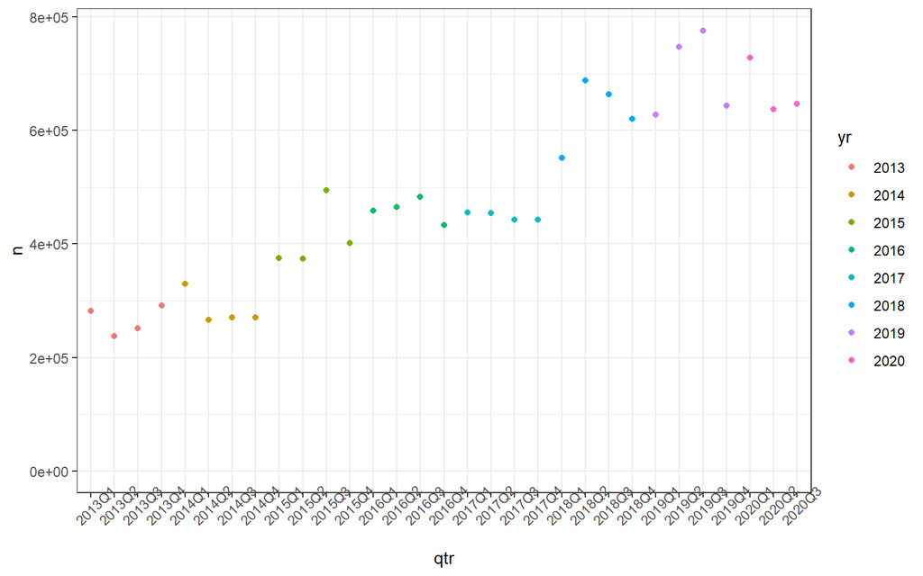

```
## #######
## ####### Max length of characters in primaryid is 11 and has 0 NA values
## ####### Max length of characters in caseid is 8 and has 0 NA values
## ####### Max length of characters in dsg_drug_seq is 3 and has 0 NA values
## ####### Max length of characters in start_dt is 8 and has 704958 NA values
## ####### Max length of characters in end_dt is 8 and has 8022363 NA values
## ####### Max length of characters in dur is 7 and has 14769605 NA values
## ####### Max length of characters in dur_cod is 5 and has 14769549 NA values
## ####### Max length of characters in qtr is 6 and has 0 NA values
## #######
## ####### The approximate postgres table definition is
## CREATE TABLE faers_dat.ther (
## primaryid     BIGINT     NOT NULL,
## caseid     BIGINT     NOT NULL,
## dsg_drug_seq     VARCHAR(3)     NOT NULL,
## start_dt     VARCHAR(8)     NULL,
## end_dt     VARCHAR(8)     NULL,
## dur     VARCHAR(7)     NULL,
## dur_cod     VARCHAR(5)     NULL,
## qtr     VARCHAR(6)     NOT NULL
## );
## #######
## Removing ther_list from the global environment to free up memory...
```

```
## [1] TRUE
```

# 9 Finally

Now, the `CSV_LOC` directory (e.g., `"C:/Users/Public/faers/csv"`) should contain the following files:

- `demo.csv`
- `drug.csv`
- `indi.csv`
- `outc.csv`
- `reac.csv`
- `rpsr.csv`
- `ther.csv`

Please see the file [`faers-ddl-and-load.sql`](https://github.com/tystan/fuzzyfaers/blob/master/postgres/faers-ddl-and-load.sql) at the Github R package tystan/fuzzyfaers which provides the SQL code to define the table import these CSVs into a PostrgreSQL database.

For completeness, please find the SQL code contained in [`faers-ddl-and-load.sql`](https://github.com/tystan/fuzzyfaers/blob/master/postgres/faers-ddl-and-load.sql) below:

```sql
/* ++++++++++++++++++++++++++++++++++++++++++++ */
/* NB:                                          */
/* the below assumes the user is `postgres` and */
/* has the permissions to create schema,        */
/* tables etc                                   */
/* ++++++++++++++++++++++++++++++++++++++++++++ */


-- create the schema you want to use
CREATE SCHEMA faers_dat
    AUTHORIZATION postgres;

SHOW search_path;
SET search_path TO faers_dat;
SHOW search_path;


/* ++++++++++++++++++++++++++++++++++++++++++++ */
/* create table structure ready for data import */
/* ++++++++++++++++++++++++++++++++++++++++++++ */


-- note I may have made some columns bigger than they strictly need to be


DROP TABLE IF EXISTS faers_dat.indi;
CREATE TABLE faers_dat.indi (
  primaryid     BIGINT     NOT NULL,
  caseid     BIGINT     NOT NULL,
  indi_drug_seq    BIGINT     NOT NULL, -- VARCHAR(3)
  indi_pt     VARCHAR(100)     NOT NULL, -- VARCHAR(93)
  qtr     VARCHAR(6)     NOT NULL
);


DROP TABLE IF EXISTS faers_dat.outc;
CREATE TABLE faers_dat.outc (
  primaryid     BIGINT     NOT NULL,
  caseid     BIGINT     NOT NULL,
  outc_cod     VARCHAR(4)     NOT NULL, -- VARCHAR(2)
  qtr     VARCHAR(6)     NOT NULL
);


DROP TABLE IF EXISTS faers_dat.reac;
CREATE TABLE faers_dat.reac (
  primaryid     BIGINT     NOT NULL,
  caseid     BIGINT     NOT NULL,
  pt     VARCHAR(100)     NOT NULL, -- VARCHAR(93)
  qtr     VARCHAR(6)     NOT NULL,
  drug_rec_act     VARCHAR(90)     NULL -- VARCHAR(66)
);


DROP TABLE IF EXISTS faers_dat.rpsr;
CREATE TABLE faers_dat.rpsr (
  primaryid     BIGINT     NOT NULL,
  caseid     BIGINT     NOT NULL,
  rpsr_cod     VARCHAR(6)     NOT NULL, -- VARCHAR(3)
  qtr     VARCHAR(6)     NOT NULL
);


DROP TABLE IF EXISTS faers_dat.ther;
CREATE TABLE faers_dat.ther (
  primaryid     BIGINT     NOT NULL,
  caseid     BIGINT     NOT NULL,
  dsg_drug_seq     BIGINT     NOT NULL, -- VARCHAR(3)
  start_dt     VARCHAR(8)     NULL,
  end_dt     VARCHAR(8)     NULL,
  dur     VARCHAR(7)     NULL,
  dur_cod     VARCHAR(10)     NULL, -- VARCHAR(5)
  qtr     VARCHAR(6)     NOT NULL
);


DROP TABLE IF EXISTS faers_dat.demo;
CREATE TABLE faers_dat.demo (
  primaryid     BIGINT     NOT NULL,
  caseid     BIGINT     NOT NULL,
  caseversion     BIGINT     NOT NULL, -- VARCHAR(3)
  i_f_code     VARCHAR(1)     NOT NULL,
  event_dt     VARCHAR(8)     NULL,
  mfr_dt     VARCHAR(8)     NULL,
  init_fda_dt     VARCHAR(8)     NOT NULL,
  fda_dt     VARCHAR(8)     NOT NULL,
  rept_cod     VARCHAR(5)      NULL,
  mfr_num     VARCHAR(90)     NULL,
  mfr_sndr     VARCHAR(65)     NULL,
  age     NUMERIC(12, 2)     NULL, -- VARCHAR(7)
  age_cod     VARCHAR(3)     NULL,
  gndr_cod     VARCHAR(3)     NULL,
  e_sub     VARCHAR(1)     NOT NULL,
  wt     VARCHAR(14)    NULL, -- VARCHAR(7) -> NUMERIC(14, 5)
  wt_cod     VARCHAR(5)     NULL,
  rept_dt     VARCHAR(8)     NULL,
  to_mfr     VARCHAR(1)     NULL,
  occp_cod     VARCHAR(5)     NULL,
  reporter_country     VARCHAR(21)     NULL,
  occr_country     VARCHAR(2)     NULL,
  qtr     VARCHAR(6)     NOT NULL,
  auth_num     VARCHAR(100)     NULL,
  lit_ref     VARCHAR(500)     NULL,
  age_grp     VARCHAR(1)     NULL,
  sex     VARCHAR(3)     NULL
);


DROP TABLE IF EXISTS faers_dat.drug;
CREATE TABLE faers_dat.drug (
  primaryid     BIGINT     NOT NULL,
  caseid     BIGINT     NOT NULL,
  drug_seq     BIGINT     NOT NULL, -- VARCHAR(3)
  role_cod     VARCHAR(2)     NULL,
  drugname     VARCHAR(500)     NULL,
  val_vbm     BIGINT     NOT NULL, -- VARCHAR(1)
  route     VARCHAR(37)     NULL,
  dose_vbm     VARCHAR(288)     NULL,
  cum_dose_chr     VARCHAR(15)     NULL,
  cum_dose_unit     VARCHAR(8)     NULL,
  dechal     VARCHAR(1)     NULL,
  rechal     VARCHAR(2)     NULL,
  lot_num     VARCHAR(363)     NULL,
  exp_dt     VARCHAR(139)     NULL,
  nda_num     VARCHAR(27)     NULL,
  dose_amt     VARCHAR(15)     NULL,
  dose_unit     VARCHAR(10)     NULL,
  dose_form     VARCHAR(50)     NULL,
  dose_freq     VARCHAR(11)     NULL,
  qtr     VARCHAR(6)     NOT NULL,
  prod_ai     VARCHAR(300)     NULL
);



/* +++++++++++++++++++++++++++++++++++++++++ */
/* Import CSVs */
/* +++++++++++++++++++++++++++++++++++++++++ */


/* Windows file locations but change for Linux or macOS */


COPY faers_dat.outc FROM 'C:/Users/Public/faers/csv/outc.csv' WITH DELIMITER ',' CSV HEADER QUOTE '"' ;
select * from faers_dat.outc limit 100;

COPY faers_dat.rpsr FROM 'C:/Users/Public/faers/csv/rpsr.csv' WITH DELIMITER ',' CSV HEADER QUOTE '"' ;
select * from faers_dat.rpsr limit 100;

COPY faers_dat.reac FROM 'C:/Users/Public/faers/csv/reac.csv' WITH DELIMITER ',' CSV HEADER QUOTE '"' ;
select * from faers_dat.reac limit 100;

COPY faers_dat.indi FROM 'C:/Users/Public/faers/csv/indi.csv' WITH DELIMITER ',' CSV HEADER QUOTE '"' ;
select * from faers_dat.indi limit 100;

COPY faers_dat.ther FROM 'C:/Users/Public/faers/csv/ther.csv' WITH DELIMITER ',' CSV HEADER QUOTE '"' ;
select * from faers_dat.ther limit 100;

COPY faers_dat.demo FROM 'C:/Users/Public/faers/csv/demo.csv' WITH DELIMITER ',' CSV HEADER QUOTE '"' ;
select * from faers_dat.demo limit 100;

/* +++++++++++++++++++++++++++++++++++++++++ */
/*
NOTE: you may get an error with the below COPY statement on Windows
please see the below comments for work-around
*/
/* +++++++++++++++++++++++++++++++++++++++++ */

COPY faers_dat.drug FROM 'C:/Users/Public/faers/csv/drug.csv' WITH DELIMITER ',' CSV HEADER QUOTE '"' ;
select * from faers_dat.drug limit 100;


/* +++++++++++++++++++++++++++++++++++++++++ */
/*

+++ work-around for large csv imports +++

NOTE: the above load into DRUG table may not work on windows because of
a bug with file sizes > 1GB

the below is a work around using WSL shell/bash on Linux

NB: the split csvs do NOT have header rows

*/
/* +++++++++++++++++++++++++++++++++++++++++ */

-- first of all you need to split the drug.csv file into smaller chunks
-- you can use the `split` utility within WSL shell/bash on Linux
-- below is the code to do so

/*

cd /mnt/c/Users/Public/faers/csv
# let's create a sub directory to keep smaller chunks
mkdir drug_split

# this creates drug textfile chunks of ~900mb each named drug01, drug02, ... etc
split -C 900m --numeric-suffixes drug.csv drug_split/drug

# now append ".csv" to each split file in drug_split/
cd drug_split
for j in *; do mv -- "$j" "${j}.csv"; done

# you are ready to go!

*/


/* NB: the split csvs do NOT have header rows except for the first one */
COPY faers_dat.drug FROM 'C:/Users/Public/faers/csv/drug_split/drug00.csv' WITH DELIMITER ',' CSV HEADER QUOTE '"' ;
select * from faers_dat.drug limit 100;
select count(*) from faers_dat.drug;-- should be ~10 mil

COPY faers_dat.drug FROM 'C:/Users/Public/faers/csv/drug_split/drug01.csv' WITH DELIMITER ',' CSV QUOTE '"' ;
select count(*) from faers_dat.drug; -- should be ~10 mil + ~10 mil = ~20 mil


COPY faers_dat.drug FROM 'C:/Users/Public/faers/csv/drug_split/drug02.csv' WITH DELIMITER ',' CSV QUOTE '"' ;
COPY faers_dat.drug FROM 'C:/Users/Public/faers/csv/drug_split/drug03.csv' WITH DELIMITER ',' CSV QUOTE '"' ;
COPY faers_dat.drug FROM 'C:/Users/Public/faers/csv/drug_split/drug04.csv' WITH DELIMITER ',' CSV QUOTE '"' ;
select count(*) from faers_dat.drug; -- ~40 mil


/* +++++++++++++++++++++++++++++++++++++++++ */
/* Create indexes etc to make queries faster */
/* +++++++++++++++++++++++++++++++++++++++++ */


CREATE INDEX idx_indi_primaryid  ON indi (primaryid ASC);
CLUSTER indi USING idx_indi_primaryid ;
CREATE INDEX idx_indi_caseid  ON indi (caseid ASC);


CREATE INDEX idx_outc_primaryid  ON outc (primaryid ASC);
CLUSTER outc USING idx_outc_primaryid ;
CREATE INDEX idx_outc_caseid  ON outc (caseid ASC);


CREATE INDEX idx_reac_primaryid ON reac (primaryid ASC);
CLUSTER reac USING idx_reac_primaryid ;
CREATE INDEX idx_reac_caseid  ON reac (caseid ASC);

CREATE INDEX idx_reac_pt  ON reac (pt ASC);

CREATE INDEX idx_rpsr_primaryid  ON rpsr (primaryid ASC);
CLUSTER rpsr USING idx_rpsr_primaryid ;
CREATE INDEX idx_rpsr_caseid  ON rpsr (caseid ASC);


CREATE INDEX idx_ther_primaryid  ON ther (primaryid ASC);
CLUSTER ther USING idx_ther_primaryid ;
CREATE INDEX idx_ther_caseid  ON ther (caseid ASC);


CREATE INDEX idx_demo_primaryid  ON demo (primaryid ASC);
CLUSTER demo USING idx_demo_primaryid ;
CREATE INDEX idx_demo_caseid  ON demo (caseid ASC);


CREATE INDEX idx_drug_primaryid  ON drug (primaryid ASC);
CLUSTER drug USING idx_drug_primaryid ;
CREATE INDEX idx_drug_caseid  ON drug (caseid ASC);

CREATE INDEX idx_drug_drugname  ON drug (drugname ASC);
CREATE INDEX idx_drug_prod_ai  ON drug (prod_ai ASC);


ALTER TABLE demo ADD CONSTRAINT xpk_demo PRIMARY KEY (primaryid,caseid,caseversion,qtr);
ALTER TABLE drug ADD CONSTRAINT xpk_drug PRIMARY KEY (primaryid,caseid,drug_seq,qtr);
```

# 10 Session information

```r
# end time of process
(time_end <- format(Sys.time(), '%Y-%m-%d %H:%M:%S'))
```

```
## [1] "2021-01-07 18:12:30"
```

```r
# how long process took
process_tme <-
  (as_datetime(time_srt) %--% as_datetime(time_end)) / minutes(1)
paste(
  "Process has taken:",
  round(process_tme, 2),
  "minutes to complete. Good day."
)
```

```
## [1] "Process has taken: 31.48 minutes to complete. Good day."
```